# Activism Pilot Analysis

Shaye

2026-09-07

# 1 Set Up

# 2 Load Processed Data

```r
# Load processed clean datasets (generated by 01_data_cleaning.Rmd)
load(find_path("data", "processed", "clean_dfs.RData"))
```

# 3 Descriptive Statistics

```r
#outcomes by condition

df_long %>%
  filter(!is.na(relative_contribution)) %>%
  group_by(treatment_assigned,is_treatment_round) %>%
  rename(Condition = treatment_assigned,
         "Treatment Round" = is_treatment_round) %>%
  summarise(
    n                = n(),
    "Avg Contribution %" = mean(relative_contribution, na.rm = TRUE),
    "Avg Contribution % (SD)"   = sd(relative_contribution, na.rm = TRUE),
    "Avg # of Activists"    = mean(num_activists, na.rm = TRUE),
    "Avg Activism Rate"    = mean(player.chose_activism, na.rm = TRUE),
    "Avg Payoff"      = mean(round_payoff, na.rm = TRUE),
    "Avg Wage" = mean(wage, na.rm = TRUE),
    "Avg Norm Wage" = mean(norm_wage, na.rm = TRUE),
    "Avg Welfare" = mean(welfare, na.rm = TRUE),
    "Avg Efficiency" = mean(efficiency, na.rm = TRUE),
    .groups = "drop"
  ) %>%
  kbl(digits = 3, caption = "Outcome means by condition - all data") %>%
  kable_styling(bootstrap_options = c("striped", "hover"), full_width = FALSE)
```

Outcome means by condition - all data

| Condition | Treatment Round | n | Avg Contribution % | Avg Contribution % (SD) | Avg # of Activists | Avg Activism Rate | Avg Payoff | Avg Wage | Avg Norm Wage | Avg Welfare | Avg Efficiency |
| --- | --- | --- | --- | --- | --- | --- | --- | --- | --- | --- | --- |
| demonstration | 0 | 104 | 20.246 | 24.62 | NaN | NaN | 113.0 | 101.44 | 2.254 | 448.7 | 69.04 |
| demonstration | 1 | 84 | 9.008 | 22.31 | 0.571 | 0.143 | 115.7 | 110.71 | 2.531 | 462.8 | 65.58 |
| petition | 0 | 152 | 32.834 | 29.14 | NaN | NaN | 118.6 | 99.93 | 2.221 | 471.9 | 74.20 |
| petition | 1 | 112 | 35.186 | 27.79 | 3.464 | 0.866 | 134.7 | 111.16 | 2.470 | 538.9 | 75.52 |
| roadblock | 0 | 104 | 32.509 | 35.64 | NaN | NaN | 117.3 | 98.46 | 2.188 | 469.4 | 74.92 |
| roadblock | 1 | 56 | 15.172 | 24.14 | 2.143 | 0.536 | 101.7 | 93.39 | 2.483 | 406.9 | 68.67 |

```r
df_long_clean %>%
  filter(!is.na(relative_contribution)) %>%
  group_by(treatment_assigned,is_treatment_round) %>%
  rename(Condition = treatment_assigned,
         "Treatment Round" = is_treatment_round) %>%
  summarise(
    n                = n(),
    "Avg Contribution %" = mean(relative_contribution, na.rm = TRUE),
    "Avg Contribution % (SD)"   = sd(relative_contribution, na.rm = TRUE),
    "Avg # of Activists"    = mean(num_activists, na.rm = TRUE),
    "Avg Activism Rate"    = mean(player.chose_activism, na.rm = TRUE),
    "Avg Payoff"      = mean(round_payoff, na.rm = TRUE),
    "Avg Wage" = mean(wage, na.rm = TRUE),
    "Avg Norm Wage" = mean(norm_wage, na.rm = TRUE),
    "Avg Welfare" = mean(welfare, na.rm = TRUE),
    "Avg Efficiency" = mean(efficiency, na.rm = TRUE),
    .groups = "drop"
  ) %>%
  kbl(digits = 3, caption = "Outcome means by condition - complete data only") %>%
  kable_styling(bootstrap_options = c("striped", "hover"), full_width = FALSE)
```

Outcome means by condition - complete data only

| Condition | Treatment Round | n | Avg Contribution % | Avg Contribution % (SD) | Avg # of Activists | Avg Activism Rate | Avg Payoff | Avg Wage | Avg Norm Wage | Avg Welfare | Avg Efficiency |
| --- | --- | --- | --- | --- | --- | --- | --- | --- | --- | --- | --- |
| demonstration | 0 | 84 | 22.271 | 26.55 | NaN | NaN | 112.6 | 100.12 | 2.225 | 450.4 | 70.07 |
| demonstration | 1 | 84 | 9.008 | 22.31 | 0.571 | 0.143 | 115.7 | 110.71 | 2.531 | 462.8 | 65.58 |
| petition | 0 | 112 | 26.895 | 24.65 | NaN | NaN | 116.6 | 101.43 | 2.254 | 466.4 | 72.32 |
| petition | 1 | 112 | 35.186 | 27.79 | 3.464 | 0.866 | 134.7 | 111.16 | 2.470 | 538.9 | 75.52 |
| roadblock | 0 | 56 | 17.817 | 21.08 | NaN | NaN | 110.0 | 99.82 | 2.218 | 440.0 | 69.37 |
| roadblock | 1 | 56 | 15.172 | 24.14 | 2.143 | 0.536 | 101.7 | 93.39 | 2.483 | 406.9 | 68.67 |

```r
#describeBy(df_questionnaire,group = "participant.treatment")

library(gtsummary)
df_questionnaire %>%
  tbl_summary(include = c(questionnaire.1.player.q1_support:questionnaire.1.player.q8_annoyance),
              by = participant.treatment,
              type = list(all_continuous() ~ "continuous2",
                          c(questionnaire.1.player.q3_personal_cost:questionnaire.1.player.q8_annoyance
                            ) ~ "continuous2"),
              statistic = list(all_continuous() ~ c("{mean} ({sd})","{median} [{min},{max}]"),
                               all_categorical() ~ "{n} ({p}%)"),
              #sort = list(everything() ~ "frequency"),
              digits = list(all_continuous() ~ 2,
                            all_categorical() ~ 2)) %>%
  add_n() %>% # add column with total number of non-missing observations
  add_overall() %>%
  add_p(pvalue_fun = ~ style_pvalue(.x, digits = 2))
```

| **Characteristic** | **N** | **Overall** N = 56<sup>1</sup> | **demonstration** N = 16<sup>1</sup> | **petition** N = 24<sup>1</sup> | **roadblock** N = 16<sup>1</sup> | **p-value**<sup>2</sup> |
| --- | --- | --- | --- | --- | --- | --- |
| questionnaire.1.player.q1_support | 36 | 19.00 (52.78%) | 3.00 (25.00%) | 11.00 (68.75%) | 5.00 (62.50%) | 0.076 |
| Unknown |  | 20 | 4 | 8 | 8 |  |
| questionnaire.1.player.q1_pressure | 36 | 4.00 (11.11%) | 1.00 (8.33%) | 2.00 (12.50%) | 1.00 (12.50%) | >0.99 |
| Unknown |  | 20 | 4 | 8 | 8 |  |
| questionnaire.1.player.q1_convincing | 36 | 8.00 (22.22%) | 1.00 (8.33%) | 6.00 (37.50%) | 1.00 (12.50%) | 0.20 |
| Unknown |  | 20 | 4 | 8 | 8 |  |
| questionnaire.1.player.q1_too_extreme | 36 | 4.00 (11.11%) | 3.00 (25.00%) | 0.00 (0.00%) | 1.00 (12.50%) | 0.066 |
| Unknown |  | 20 | 4 | 8 | 8 |  |
| questionnaire.1.player.q1_no_earnings_effect | 36 | 11.00 (30.56%) | 4.00 (33.33%) | 6.00 (37.50%) | 1.00 (12.50%) | 0.58 |
| Unknown |  | 20 | 4 | 8 | 8 |  |
| questionnaire.1.player.q1_reciprocate | 36 | 6.00 (16.67%) | 0.00 (0.00%) | 6.00 (37.50%) | 0.00 (0.00%) | 0.011 |
| Unknown |  | 20 | 4 | 8 | 8 |  |
| questionnaire.1.player.q1_autonomy | 36 | 5.00 (13.89%) | 3.00 (25.00%) | 0.00 (0.00%) | 2.00 (25.00%) | 0.056 |
| Unknown |  | 20 | 4 | 8 | 8 |  |
| questionnaire.1.player.q1_motivation_other | 8 |  |  |  |  | >0.99 |
| evidently cooperation would bring us the biggest profit and in the first rounds i wanted to establlish trust by my contributions |  | 1.00 (12.50%) | 0.00 (0.00%) | 1.00 (33.33%) | 0.00 (0.00%) |  |
| higher payoff |  | 1.00 (12.50%) | 0.00 (0.00%) | 1.00 (33.33%) | 0.00 (0.00%) |  |
| I am not interested, I dislike group projects |  | 1.00 (12.50%) | 1.00 (25.00%) | 0.00 (0.00%) | 0.00 (0.00%) |  |
| I wanted to earn more points through cooperation |  | 1.00 (12.50%) | 0.00 (0.00%) | 1.00 (33.33%) | 0.00 (0.00%) |  |
| I wanted to put the money in a pot but hardly anyone else participated so it was no good deal for me in the end. |  | 1.00 (12.50%) | 0.00 (0.00%) | 0.00 (0.00%) | 1.00 (100.00%) |  |
| Not being an activist and still sharing would have been the most effecient option for everybody involved |  | 1.00 (12.50%) | 1.00 (25.00%) | 0.00 (0.00%) | 0.00 (0.00%) |  |
| Not regarding that but sometimes the numbers got changed to an incorrect number |  | 1.00 (12.50%) | 1.00 (25.00%) | 0.00 (0.00%) | 0.00 (0.00%) |  |
| taking away time did not seem like a good idea to me |  | 1.00 (12.50%) | 1.00 (25.00%) | 0.00 (0.00%) | 0.00 (0.00%) |  |
| Unknown |  | 48 | 12 | 21 | 15 |  |
| questionnaire.1.player.q2_activism_choice | 36 |  |  |  |  | 0.17 |
| Demonstration (Cost: -10 sec to you) |  | 1.00 (2.78%) | 1.00 (8.33%) | 0.00 (0.00%) | 0.00 (0.00%) |  |
| None of the above |  | 5.00 (13.89%) | 1.00 (8.33%) | 3.00 (18.75%) | 1.00 (12.50%) |  |
| Petition (0 cost to you) |  | 28.00 (77.78%) | 10.00 (83.33%) | 13.00 (81.25%) | 5.00 (62.50%) |  |
| Road blocking (Cost: -10 sec to you; -5 sec to others) |  | 2.00 (5.56%) | 0.00 (0.00%) | 0.00 (0.00%) | 2.00 (25.00%) |  |
| Unknown |  | 20 | 4 | 8 | 8 |  |
| questionnaire.1.player.q3_personal_cost | 36 |  |  |  |  | <0.001 |
| Mean (SD) |  | 3.08 (1.46) | 4.25 (0.87) | 2.00 (1.26) | 3.50 (0.93) |  |
| Median [Min,Max] |  | 3.00 [1.00,5.00] | 4.50 [3.00,5.00] | 1.50 [1.00,5.00] | 3.50 [2.00,5.00] |  |
| Unknown |  | 20 | 4 | 8 | 8 |  |
| questionnaire.1.player.q4_cost_to_others | 36 |  |  |  |  | 0.13 |
| Mean (SD) |  | 2.97 (1.23) | 2.42 (1.38) | 3.13 (1.15) | 3.50 (0.93) |  |
| Median [Min,Max] |  | 3.00 [1.00,5.00] | 2.00 [1.00,5.00] | 3.00 [1.00,5.00] | 3.50 [2.00,5.00] |  |
| Unknown |  | 20 | 4 | 8 | 8 |  |
| questionnaire.1.player.q5_extremity | 36 |  |  |  |  | 0.96 |
| Mean (SD) |  | 2.61 (1.08) | 2.58 (1.16) | 2.63 (1.09) | 2.63 (1.06) |  |
| Median [Min,Max] |  | 2.50 [1.00,5.00] | 2.50 [1.00,5.00] | 3.00 [1.00,4.00] | 2.00 [2.00,5.00] |  |
| Unknown |  | 20 | 4 | 8 | 8 |  |
| questionnaire.1.player.q6_legitimacy | 36 |  |  |  |  | 0.066 |
| Mean (SD) |  | 3.36 (1.15) | 2.83 (0.94) | 3.69 (1.30) | 3.50 (0.93) |  |
| Median [Min,Max] |  | 4.00 [1.00,5.00] | 3.00 [1.00,4.00] | 4.00 [1.00,5.00] | 3.50 [2.00,5.00] |  |
| Unknown |  | 20 | 4 | 8 | 8 |  |
| questionnaire.1.player.q7_social_id | 36 |  |  |  |  | 0.22 |
| Mean (SD) |  | 2.97 (1.03) | 2.67 (1.07) | 3.31 (1.01) | 2.75 (0.89) |  |
| Median [Min,Max] |  | 3.00 [1.00,5.00] | 3.00 [1.00,4.00] | 3.00 [1.00,5.00] | 2.50 [2.00,4.00] |  |
| Unknown |  | 20 | 4 | 8 | 8 |  |
| questionnaire.1.player.q8_compassion | 36 |  |  |  |  | 0.19 |
| Mean (SD) |  | 2.94 (0.89) | 2.67 (0.89) | 2.94 (0.93) | 3.38 (0.74) |  |
| Median [Min,Max] |  | 3.00 [1.00,5.00] | 3.00 [1.00,4.00] | 3.00 [1.00,5.00] | 3.50 [2.00,4.00] |  |
| Unknown |  | 20 | 4 | 8 | 8 |  |
| questionnaire.1.player.q8_sympathy | 36 |  |  |  |  | 0.36 |
| Mean (SD) |  | 3.03 (0.97) | 2.67 (1.07) | 3.25 (0.77) | 3.13 (1.13) |  |
| Median [Min,Max] |  | 3.00 [1.00,5.00] | 3.00 [1.00,4.00] | 3.00 [2.00,5.00] | 3.50 [1.00,4.00] |  |
| Unknown |  | 20 | 4 | 8 | 8 |  |
| questionnaire.1.player.q8_annoyance | 36 |  |  |  |  | >0.99 |
| Mean (SD) |  | 2.64 (0.99) | 2.67 (1.07) | 2.63 (1.02) | 2.63 (0.92) |  |
| Median [Min,Max] |  | 3.00 [1.00,5.00] | 3.00 [1.00,5.00] | 2.50 [1.00,4.00] | 3.00 [1.00,4.00] |  |
| Unknown |  | 20 | 4 | 8 | 8 |  |

<sup>1</sup> n (%)  
<sup>2</sup> Fisher’s exact test; Kruskal-Wallis rank sum test

# 4 Main Analysis & Plots

Prereg: https://osf.io/uz3h9/overview

## 4.1 H1: Contribution Rate

### 4.1.1 OLS (Main Specification)

```r
#1. OLS: main preregistered model - all groups
model_h1_ols <- lm(relative_contribution ~ condition + period,
                   data = df_long)

# Cluster-robust SEs at group level
vcov_h1_ols <- vcovCL(model_h1_ols, cluster = ~ group_id)
coeftest(model_h1_ols, vcov = vcov_h1_ols)
```

```
##
## t test of coefficients:
##
##                        Estimate Std. Error t value         Pr(>|t|)
## (Intercept)              39.524      5.199    7.60 0.00000000000011 ***
## conditionpetition        25.651      9.854    2.60           0.0095 **
## conditiondemonstration   -0.527      7.829   -0.07           0.9464
## conditionroadblock        5.637     11.165    0.50           0.6138
## period                   -2.726      0.686   -3.97 0.00007945196354 ***
## ---
## Signif. codes:  0 '***' 0.001 '**' 0.01 '*' 0.05 '.' 0.1 ' ' 1
```

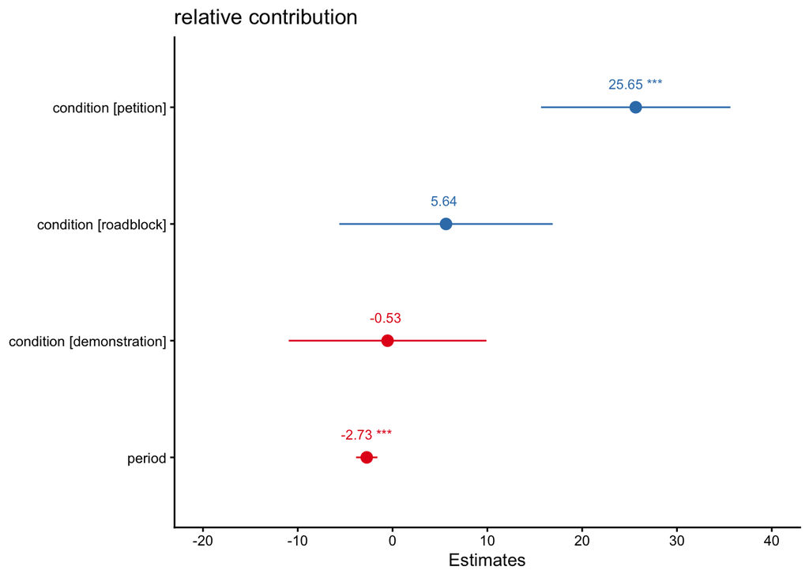

```r
plot_model(model_h1_ols,
           show.values=T,show.p=T,  sort.est = T,#colors = condition_colors,
           bpe.style = "dot", value.offset = .2,dot.size = 3,#mdrt.values ="meansd",
                     jitter = 1, value.size = 3,line.size = .5) + theme_classic()
```

```r
#cleaner version but slightly more conservative results
model_h1_ols_rob <- estimatr::lm_robust(relative_contribution ~ condition + period,
                   data = df_long,
                   clusters = group_id,
                   se_type = "CR2") #because small sample
tab_model(model_h1_ols_rob)
```

|  | relative contribution |  |  |
| --- | --- | --- | --- |
| Predictors | Estimates | CI | p |
| (Intercept) | 39.52 | 29.33 – 49.71 | **<0.001** |
| condition [petition] | 25.65 | 4.71 – 46.59 | **0.016** |
| condition [demonstration] | -0.53 | -16.47 – 15.42 | 0.948 |
| condition [roadblock] | 5.64 | -20.27 – 31.55 | 0.669 |
| period | -2.73 | -4.08 – -1.37 | **<0.001** |
| Observations | 612 |  |  |
| R<sup>2</sup> / R<sup>2</sup> adjusted | 0.115 / 0.109 |  |  |

```r
#2. estimated marginal means
emm_df <- emmeans(model_h1_ols, pairwise ~ condition, adjust = "holm")
nice_table((emmeans(model_h1_ols, pairwise ~ condition, adjust = "holm")$emmeans))
```

| condition | emmean | SE | df | 95% CI |
| --- | --- | --- | --- | --- |
| control | 21.05 | 2.24 | 607 | [16.65, 25.44] |
| petition | 46.70 | 3.57 | 607 | [39.68, 53.71] |
| demonstration | 20.52 | 3.88 | 607 | [12.89, 28.15] |
| roadblock | 26.68 | 4.44 | 607 | [17.96, 35.41] |

```r
nice_table((emmeans(model_h1_ols, pairwise ~ condition, adjust = "holm")$contrasts))
```

| contrast | estimate | SE | df | t | p |
| --- | --- | --- | --- | --- | --- |
| control - petition | -25.65 | 5.09 | 607 | -5.04 | < .001*** |
| control - demonstration | 0.53 | 5.31 | 607 | 0.10 | .921 |
| control - roadblock | -5.64 | 5.73 | 607 | -0.98 | .652 |
| petition - demonstration | 26.18 | 4.03 | 607 | 6.49 | < .001*** |
| petition - roadblock | 20.01 | 4.57 | 607 | 4.38 | < .001*** |
| demonstration - roadblock | -6.16 | 4.82 | 607 | -1.28 | .605 |

```r
# Save pairwise contrasts (Holm-adjusted) for the appendix
h1_contrasts_df <- as.data.frame(
  emmeans(model_h1_ols, pairwise ~ condition, adjust = "holm")$contrasts
) %>%
  transmute(
    Contrast = paste(str_to_title(gsub(" - .*", "", contrast)), "vs.",
                      str_to_title(gsub(".*- ", "", contrast))),
    Estimate = round(estimate, 2),
    SE = round(SE, 2),
    df = round(df, 0),
    t = round(t.ratio, 2),
    p = ifelse(p.value < 0.001, "<0.001", sprintf("%.3f", p.value))
  )
modelsummary::datasummary_df(h1_contrasts_df, output = paper_path("tables", "results", "h1_contrasts.tex"))
```

```r
strip_table_wrapper(paper_path("tables", "results", "h1_contrasts.tex"))




#3. anova version
model_h1_aov <- aov(relative_contribution ~ condition + as.factor(period),
                   data = df_long)
summary(model_h1_aov)
```

```
##                    Df Sum Sq Mean Sq F value         Pr(>F)
## condition           3  43716   14572   18.57 0.000000000016 ***
## as.factor(period)  12  24373    2031    2.59         0.0023 **
## Residuals         596 467667     785
## ---
## Signif. codes:  0 '***' 0.001 '**' 0.01 '*' 0.05 '.' 0.1 ' ' 1
```

```r
TukeyHSD(model_h1_aov) #less conservative than emmeans; rb & demo sig relative to control
```

```
##   Tukey multiple comparisons of means
##     95% family-wise confidence level
##
## Fit: aov(formula = relative_contribution ~ condition + as.factor(period), data = df_long)
##
## $condition
##                            diff     lwr     upr  p adj
## petition-control          6.082  -1.726  13.890 0.1866
## demonstration-control   -20.096 -28.840 -11.351 0.0000
## roadblock-control       -13.931 -24.298  -3.565 0.0032
## demonstration-petition  -26.178 -36.594 -15.761 0.0000
## roadblock-petition      -20.014 -31.825  -8.202 0.0001
## roadblock-demonstration   6.164  -6.286  18.614 0.5789
##
## $`as.factor(period)`
##            diff     lwr    upr  p adj
## 2-1    -0.75932 -18.587 17.068 1.0000
## 3-1    -0.79281 -18.620 17.035 1.0000
## 4-1     0.49206 -17.675 18.659 1.0000
## 5-1    -8.35385 -26.521  9.813 0.9579
## 6-1    -4.65660 -23.661 14.348 0.9999
## 7-1   -13.26607 -32.270  5.738 0.5178
## 8-1     6.65165 -13.500 26.804 0.9979
## 9-1     9.13866 -11.013 29.291 0.9623
## 10-1   -1.36095 -21.513 18.791 1.0000
## 11-1   -7.16122 -27.313 12.991 0.9957
## 12-1   -8.59670 -28.749 11.555 0.9772
## 13-1   -9.13575 -29.288 11.016 0.9624
## 14-1  -14.50877 -34.661  5.643 0.4635
## 3-2    -0.03349 -17.861 17.794 1.0000
## 4-2     1.25138 -16.916 19.419 1.0000
## 5-2    -7.59454 -25.762 10.573 0.9809
## 6-2    -3.89729 -22.902 15.107 1.0000
## 7-2   -12.50676 -31.511  6.498 0.6178
## 8-2     7.41097 -12.741 27.563 0.9940
## 9-2     9.89798 -10.254 30.050 0.9306
## 10-2   -0.60163 -20.754 19.551 1.0000
## 11-2   -6.40191 -26.554 13.750 0.9986
## 12-2   -7.83738 -27.990 12.315 0.9899
## 13-2   -8.37643 -28.529 11.776 0.9818
```

[output cut: 52 more lines]

```
## 10-9  -10.49961 -32.735 11.735 0.9483
## 11-9  -16.29988 -38.535  5.935 0.4318
## 12-9  -17.73536 -39.970  4.500 0.2895
## 13-9  -18.27441 -40.509  3.961 0.2439
## 14-9  -23.64743 -45.882 -1.412 0.0250
## 11-10  -5.80027 -28.035 16.435 0.9998
## 12-10  -7.23575 -29.471 14.999 0.9982
## 13-10  -7.77480 -30.010 14.460 0.9963
## 14-10 -13.14782 -35.383  9.087 0.7728
## 12-11  -1.43548 -23.670 20.799 1.0000
## 13-11  -1.97453 -24.209 20.260 1.0000
## 14-11  -7.34755 -29.583 14.887 0.9979
## 13-12  -0.53905 -22.774 21.696 1.0000
## 14-12  -5.91207 -28.147 16.323 0.9998
## 14-13  -5.37303 -27.608 16.862 0.9999
```

```r
#results different when tobit model used (demonstration effect becomes neg)

model_h1_tobit <- tobit(relative_contribution ~ condition + period,
                        left  = 0, right = 100,
                        data  = df_long)

vcov_h1_tobit <- vcovCL(model_h1_tobit, cluster = ~ group_id)
coeftest(model_h1_tobit, vcov = vcov_h1_tobit)
```

```
##
## z test of coefficients:
##
##                        Estimate Std. Error z value             Pr(>|z|)
## (Intercept)              41.349      7.370    5.61           0.00000002 ***
## conditionpetition        41.196     13.313    3.09               0.0020 **
## conditiondemonstration  -14.785     16.422   -0.90               0.3679
## conditionroadblock       17.140     16.904    1.01               0.3106
## period                   -4.568      1.291   -3.54               0.0004 ***
## Log(scale)                3.701      0.128   28.97 < 0.0000000000000002 ***
## ---
## Signif. codes:  0 '***' 0.001 '**' 0.01 '*' 0.05 '.' 0.1 ' ' 1
```

```r
nice_table((emmeans(model_h1_tobit, pairwise ~ condition, adjust = "holm")$emmeans))
```

| condition | emmean | SE | df | 95% CI |
| --- | --- | --- | --- | --- |
| control | 10.38 | 3.50 | 606 | [3.51, 17.26] |
| petition | 51.58 | 5.37 | 606 | [41.04, 62.12] |
| demonstration | -4.40 | 6.75 | 606 | [-17.66, 8.86] |
| roadblock | 27.52 | 6.75 | 606 | [14.27, 40.77] |

```r
nice_table((emmeans(model_h1_tobit, pairwise ~ condition, adjust = "holm")$contrasts))
```

| contrast | estimate | SE | df | t | p |
| --- | --- | --- | --- | --- | --- |
| control - petition | -41.20 | 7.80 | 606 | -5.28 | < .001*** |
| control - demonstration | 14.79 | 8.66 | 606 | 1.71 | .103 |
| control - roadblock | -17.14 | 8.79 | 606 | -1.95 | .103 |
| petition - demonstration | 55.98 | 7.04 | 606 | 7.95 | < .001*** |
| petition - roadblock | 24.06 | 6.89 | 606 | 3.49 | .002** |
| demonstration - roadblock | -31.92 | 8.13 | 606 | -3.93 | < .001*** |

```r
#v2 with treatment_assigned instead of condition
model_h1b_ols <- lm(relative_contribution ~ treatment_assigned * is_treatment_round + period,
                   data = df_long)
summary(model_h1b_ols)
```

```
##
## Call:
## lm(formula = relative_contribution ~ treatment_assigned * is_treatment_round +
##     period, data = df_long)
##
## Residuals:
##    Min     1Q Median     3Q    Max
## -43.39 -17.89  -6.81   9.81  85.52
##
## Coefficients:
##                                                Estimate Std. Error t value
## (Intercept)                                      30.658      3.459    8.86
## treatment_assignedpetition                       12.683      3.519    3.60
## treatment_assignedroadblock                      12.263      3.835    3.20
## is_treatment_round                                8.430      5.736    1.47
## period                                           -2.735      0.564   -4.85
## treatment_assignedpetition:is_treatment_round    13.495      5.321    2.54
## treatment_assignedroadblock:is_treatment_round   -6.099      6.120   -1.00
##                                                            Pr(>|t|)
## (Intercept)                                    < 0.0000000000000002 ***
## treatment_assignedpetition                                  0.00034 ***
## treatment_assignedroadblock                                 0.00146 **
## is_treatment_round                                          0.14219
## period                                                    0.0000016 ***
## treatment_assignedpetition:is_treatment_round               0.01145 *
## treatment_assignedroadblock:is_treatment_round              0.31941
## ---
## Signif. codes:  0 '***' 0.001 '**' 0.01 '*' 0.05 '.' 0.1 ' ' 1
##
## Residual standard error: 27.7 on 605 degrees of freedom
## Multiple R-squared:  0.137,  Adjusted R-squared:  0.128
## F-statistic:   16 on 6 and 605 DF,  p-value: <0.0000000000000002
```

```r
vcov_h1b_ols <- vcovCL(model_h1b_ols, cluster = ~ group_id)
coeftest(model_h1b_ols, vcov = vcov_h1b_ols)
```

```
##
## t test of coefficients:
##
##                                                Estimate Std. Error t value
## (Intercept)                                      30.658      7.819    3.92
## treatment_assignedpetition                       12.683     10.484    1.21
## treatment_assignedroadblock                      12.263     11.615    1.06
## is_treatment_round                                8.430      8.384    1.01
## period                                           -2.735      0.671   -4.07
## treatment_assignedpetition:is_treatment_round    13.495     12.091    1.12
## treatment_assignedroadblock:is_treatment_round   -6.099     10.377   -0.59
##                                                Pr(>|t|)
## (Intercept)                                    0.000098 ***
## treatment_assignedpetition                         0.23
## treatment_assignedroadblock                        0.29
## is_treatment_round                                 0.32
## period                                         0.000053 ***
## treatment_assignedpetition:is_treatment_round      0.26
## treatment_assignedroadblock:is_treatment_round     0.56
## ---
## Signif. codes:  0 '***' 0.001 '**' 0.01 '*' 0.05 '.' 0.1 ' ' 1
```

```r
nice_table((emmeans(model_h1b_ols, pairwise ~ treatment_assigned * is_treatment_round, adjust = "holm")$emmeans))
```

| treatment_assigned | is_treatment_round | emmean | SE | df | 95% CI |
| --- | --- | --- | --- | --- | --- |
| demonstration | 0.00 | 12.12 | 3.19 | 605 | [5.86, 18.38] |
| petition | 0.00 | 24.81 | 2.79 | 605 | [19.33, 30.28] |
| roadblock | 0.00 | 24.39 | 3.19 | 605 | [18.13, 30.65] |
| demonstration | 1.00 | 20.55 | 3.84 | 605 | [13.01, 28.10] |
| petition | 1.00 | 46.73 | 3.53 | 605 | [39.79, 53.67] |
| roadblock | 1.00 | 26.72 | 4.40 | 605 | [18.09, 35.35] |

```r
# Save estimated marginal means (Condition x Phase) for the appendix
emm_h1b_df <- as.data.frame(
  emmeans(model_h1b_ols, pairwise ~ treatment_assigned * is_treatment_round, adjust = "holm")$emmeans
) %>%
  transmute(
    Condition = str_to_title(as.character(treatment_assigned)),
    Phase = if_else(is_treatment_round == 1, "Treatment", "Control"),
    Mean = round(emmean, 2),
    SE = round(SE, 2),
    df = round(df, 1),
    `Lower CI` = round(lower.CL, 2),
    `Upper CI` = round(upper.CL, 2)
  )
modelsummary::datasummary_df(emm_h1b_df, output = paper_path("tables", "results", "emm_h1b.tex"))
```

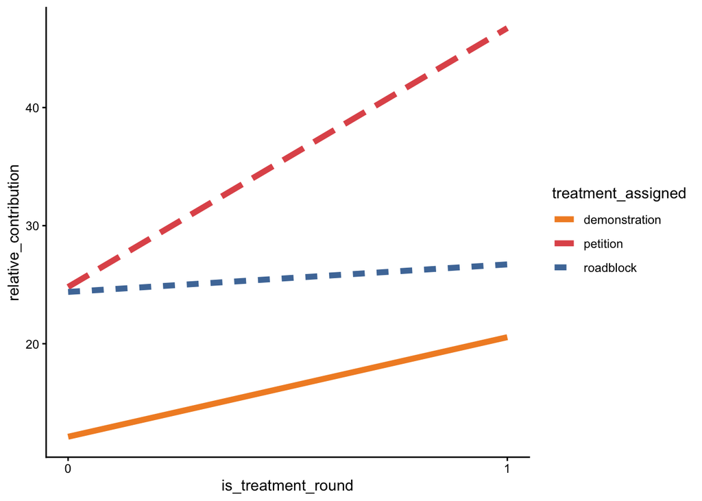

```r
strip_table_wrapper(paper_path("tables", "results", "emm_h1b.tex"))

interact_plot(model_h1b_ols, pred = "is_treatment_round",modx = "treatment_assigned",
              #plot.points = T,
              #rug = T,jitter = .1,
              #interval = T,
              robust = T,line.thickness = 2,int.type = "confidence",
              colors = c("#F28E2BFF", "#E15759FF","#4E79A7FF")) +
  theme_classic()
```

### 4.1.3 Figs: Contribution Rate

#### 4.1.3.1 1a. Main Effects (Preregistered)

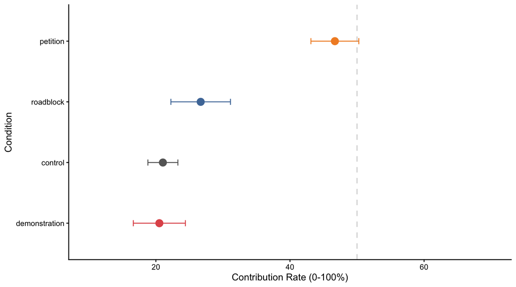

```r
#650x400

# dynamic Holm-adjusted stars from emm_df (already uses adjust = "holm")
emm_h1_vals <- tidy(emm_df$emmeans) %>% select(condition, emm_est = estimate)

sig_h1 <- tidy(emm_df$contrasts) %>%
  mutate(
    grp1  = str_trim(str_split_fixed(contrast, " - ", 2)[, 1]),
    grp2  = str_trim(str_split_fixed(contrast, " - ", 2)[, 2]),
    stars = case_when(
      adj.p.value < 0.001 ~ "***",
      adj.p.value < 0.01  ~ "**",
      adj.p.value < 0.05  ~ "*",
      TRUE                ~ "ns"
    )
  ) %>%
  filter(stars != "ns") %>%
  left_join(emm_h1_vals, by = c("grp1" = "condition")) %>% rename(e1 = emm_est) %>%
  left_join(emm_h1_vals, by = c("grp2" = "condition")) %>% rename(e2 = emm_est) %>%
  mutate(y_pos = pmax(e1, e2) + 2 + (row_number() - 1) * 3)

ggplot(tidy(emm_df$emmeans), aes(x = reorder(condition, estimate), y = estimate, colour = condition)) +
  geom_point(size = 4) +
  geom_errorbar(aes(ymin = estimate - std.error, ymax = estimate + std.error), width = 0.1) +
  #geom_signif(
  #  comparisons = map2(sig_h1$grp1, sig_h1$grp2, ~ c(.x, .y)),
  #  annotations = sig_h1$stars,
  #  y_position  = sig_h1$y_pos + 5,
  #  tip_length  = 0.01,
  #  vjust       = -0.2,
  #  colour      = "darkgray") +
  scale_colour_manual(values = condition_colors) +
  labs(#title = "Estimated Marginal Means: Contribution Rate by Condition",
       #subtitle = "OLS with cluster-robust SEs (clustered by group)",
       x = "Condition", y = "Contribution Rate (0-100%)",
       colour = NULL) +
  theme_classic(base_size = 12) +
  theme(legend.position = "none") +
  geom_hline(yintercept = 50, colour = "darkgray", alpha = .4, size = 0.8, linetype = "dashed") +
  coord_flip() +
  ylim(c(10, 70))
```

```r
summary(df_long$relative_contribution)
```

```
##    Min. 1st Qu.  Median    Mean 3rd Qu.    Max.
##     0.0     0.0    16.7    26.2    40.0   100.0
```

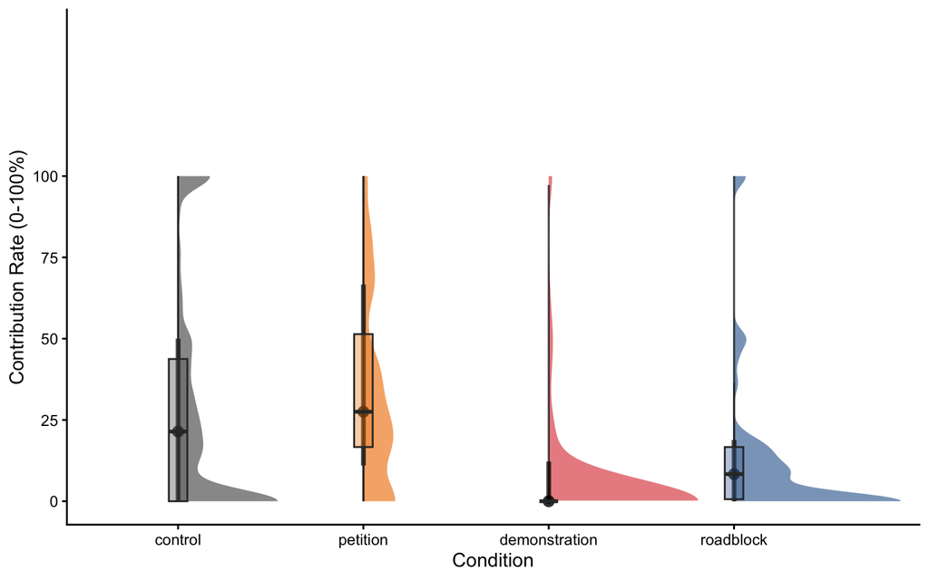

```r
fig_1_1_contribution <- df_long %>%
  ggplot(aes(x = condition, y = relative_contribution, fill = condition)) +
  ggdist::stat_halfeye(alpha = 0.7, adjust = 0.8) +
  geom_boxplot(width = 0.1, outlier.shape = NA, alpha = 0.4) +
  scale_fill_manual(values = condition_colors) +
  labs(#title = "Contribution Rate by Condition",
       x = "Condition", y = "Contribution Rate (0-100%)", fill = NULL) +
  theme_classic(base_size = 12) +
  theme(legend.position = "none") +
  scale_y_continuous(breaks = seq(0, 100, 25), limits = c(0, 120 + nrow(sig_h1) * 8)) +
  coord_cartesian(ylim = c(0, 120 + nrow(sig_h1) * 8))
  #geom_signif(
  #  comparisons = map2(sig_h1$grp1, sig_h1$grp2, ~ c(.x, .y)),
  #  annotations = sig_h1$stars,
  #  y_position  = 105 + (seq_len(nrow(sig_h1)) - 1) * 8,
  #  tip_length  = 0.01,
  #  vjust       = -0.2,
  #  colour      = "darkgray")

fig_1_1_contribution
```

```r
ggsave(paper_path("figures", "results", "1.1.contribution.png"), fig_1_1_contribution,
       width = 8, height = 5, dpi = 300, bg = "white")
```

#### 4.1.3.2 1b. Main Effects (Pre-Post)

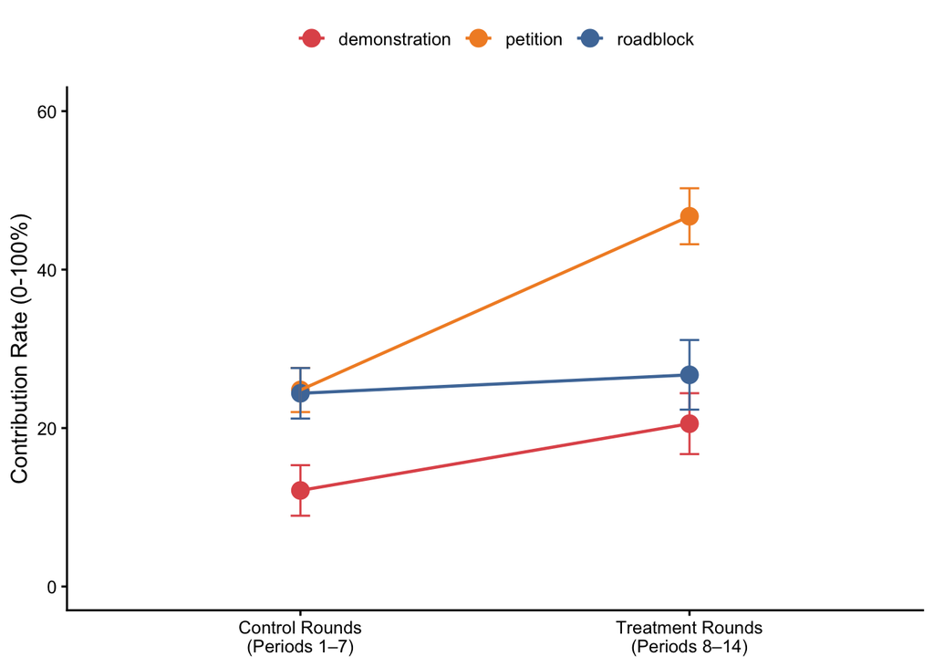

```r
emm_phase <- emmeans(model_h1b_ols, ~ treatment_assigned * is_treatment_round,
                     at = list(is_treatment_round = c(0, 1))) %>%
  tidy() %>%
  mutate(phase = factor(
    if_else(is_treatment_round == 0, "Control Rounds\n(Periods 1–7)", "Treatment Rounds\n(Periods 8–14)"),
    levels = c("Control Rounds\n(Periods 1–7)", "Treatment Rounds\n(Periods 8–14)")
  ))

# pairwise contrasts between conditions at treatment phase only
tx_contrasts <- emmeans(model_h1b_ols, pairwise ~ treatment_assigned,
                        at = list(is_treatment_round = 1),
                        adjust = "holm")$contrasts %>%
  tidy() %>%
  mutate(
    grp1  = str_trim(str_split_fixed(contrast, " - ", 2)[, 1]),
    grp2  = str_trim(str_split_fixed(contrast, " - ", 2)[, 2]),
    stars = case_when(
      adj.p.value < 0.001 ~ "***",
      adj.p.value < 0.01  ~ "**",
      adj.p.value < 0.05  ~ "*",
      TRUE                ~ "ns"
    )
  ) %>%
  filter(stars != "ns")

# y-positions at treatment phase for bracket placement
tx_ypos <- emm_phase %>%
  filter(is_treatment_round == 1) %>%
  select(treatment_assigned, estimate) %>%
  deframe()

# bracket coordinates: vertical segment to the right of x=2, one per sig pair
bracket_data <- tx_contrasts %>%
  mutate(
    y1    = map_dbl(grp1, ~ tx_ypos[.x]),
    y2    = map_dbl(grp2, ~ tx_ypos[.x]),
    x_off = 2 + row_number() * 0.08
  )

p_phase <- ggplot(emm_phase, aes(x = phase, y = estimate, colour = treatment_assigned, group = treatment_assigned)) +
  geom_point(size = 4) +
  geom_line(linewidth = 0.8) +
  geom_errorbar(aes(ymin = estimate - std.error, ymax = estimate + std.error), width = 0.05) +
  scale_colour_manual(values = treatment_colors) +
  labs(#title = "Contribution Rate: Control vs Treatment Rounds",
       x = NULL, y = "Contribution Rate (0-100%)", colour = NULL) +
  theme_classic(base_size = 12)

# significance-star brackets disabled (headers/stars now live in the caption, not the figure)
if (FALSE && nrow(bracket_data) > 0) {
  p_phase <- p_phase +
    geom_segment(data = bracket_data,
                 aes(x = x_off, xend = x_off, y = y1, yend = y2),
                 inherit.aes = FALSE, colour = "grey40", linewidth = 0.4) +
    geom_segment(data = bracket_data,
                 aes(x = x_off - 0.02, xend = x_off, y = y1, yend = y1),
                 inherit.aes = FALSE, colour = "grey40", linewidth = 0.4) +
    geom_segment(data = bracket_data,
                 aes(x = x_off - 0.02, xend = x_off, y = y2, yend = y2),
                 inherit.aes = FALSE, colour = "grey40", linewidth = 0.4) +
    geom_text(data = bracket_data,
              aes(x = x_off + 0.04, y = (y1 + y2) / 2, label = stars),
              inherit.aes = FALSE, colour = "grey40", size = 4)
}

fig1_panelA <- p_phase +
  coord_cartesian(xlim = c(1, 2), ylim = c(0, 60), clip = "off") +
  theme(legend.position = "top")

fig1_panelA
```

```r
ggsave(paper_path("figures", "results", "1.2.contributionprepost.png"), fig1_panelA,
       width = 8, height = 5, dpi = 300, bg = "white")
```

#### 4.1.3.3 1c. Main Effects (Over Time)

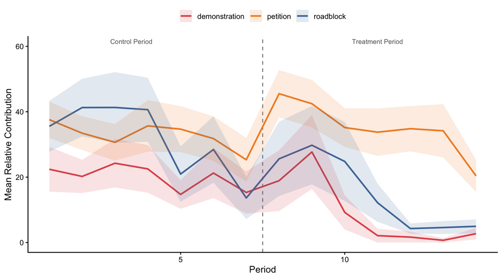

```r
fig1_panelB <- df_long %>%
  #filter(!is.na(relative_contribution)) %>%
  group_by(period, treatment_assigned) %>%
  summarise(mean_rc = mean(relative_contribution, na.rm = TRUE),
            se_rc   = sd(relative_contribution, na.rm = TRUE) / sqrt(n()),
            .groups = "drop") %>%
  ggplot(aes(x = period, y = mean_rc, colour = treatment_assigned, group = treatment_assigned)) +
  geom_vline(xintercept = 7.5, linetype = "dashed", colour = "grey50") +
  geom_line(linewidth = 1) +
  geom_ribbon(aes(ymin = mean_rc - se_rc, ymax = mean_rc + se_rc, fill = treatment_assigned),
              alpha = 0.15, colour = NA) +
  scale_colour_manual(values = treatment_colors) +
  scale_fill_manual(values = treatment_colors) +
  annotate("text", x = 3.5, y = Inf, label = "Control Period", vjust = 1.5,
           colour = "grey40", size = 3) +
  annotate("text", x = 11,  y = Inf, label = "Treatment Period",   vjust = 1.5,
           colour = "grey40", size = 3) +
  labs(#title = "Mean Relative Contribution Over Time",
       x = "Period", y = "Mean Relative Contribution",
       colour = NULL, fill = NULL) +
  theme_classic(base_size = 12) +
  ylim(c(0,60)) +
  #scale_x_continuous(breaks = c(2,4,8,6,10,12,14)) +
  theme(legend.position = "top")

fig1_panelB
```

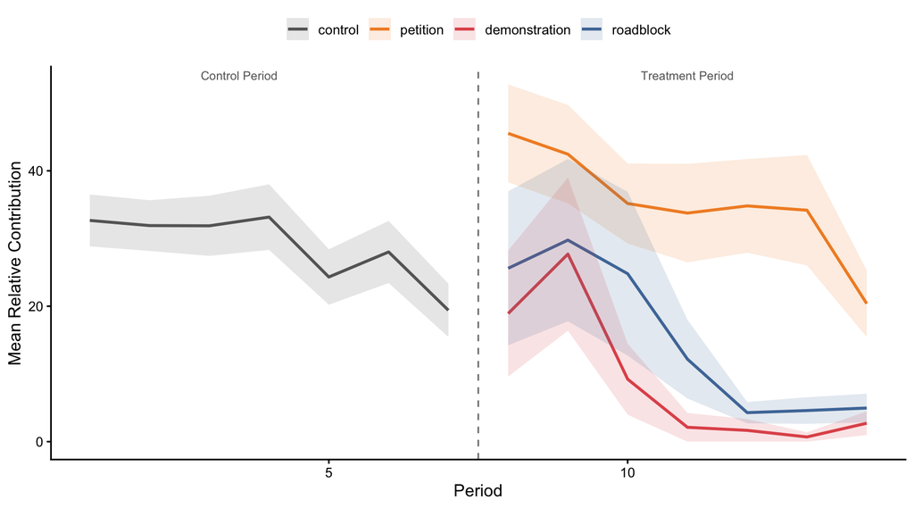

```r
ggsave(paper_path("figures", "results", "1.4.contributionovertime.png"), fig1_panelB,
       width = 9, height = 5, dpi = 300, bg = "white")


df_long %>%
  filter(!is.na(relative_contribution)) %>%
  group_by(period, condition) %>%
  summarise(mean_rc = mean(relative_contribution, na.rm = TRUE),
            se_rc   = sd(relative_contribution, na.rm = TRUE) / sqrt(n()),
            .groups = "drop") %>%
  ggplot(aes(x = period, y = mean_rc, colour = condition, group = condition)) +
  geom_vline(xintercept = 7.5, linetype = "dashed", colour = "grey50") +
  geom_line(linewidth = 1) +
  geom_ribbon(aes(ymin = mean_rc - se_rc, ymax = mean_rc + se_rc, fill = condition),
              alpha = 0.15, colour = NA) +
  scale_colour_manual(values = condition_colors) +
  scale_fill_manual(values = condition_colors) +
  annotate("text", x = 3.5, y = Inf, label = "Control Period", vjust = 1.5,
           colour = "grey40", size = 3) +
  annotate("text", x = 11,  y = Inf, label = "Treatment Period",   vjust = 1.5,
           colour = "grey40", size = 3) +
  labs(#title = "Mean Relative Contribution Over Time",
       x = "Period", y = "Mean Relative Contribution",
       colour = NULL, fill = NULL) +
  theme_classic(base_size = 12) +
  #scale_x_continuous(breaks = c(2,4,8,6,10,12,14)) +
  theme(legend.position = "top")
```

#### 4.1.3.4 1d. Figure 1: Combined Panels (Control vs. Treatment Round + Contribution over Period)

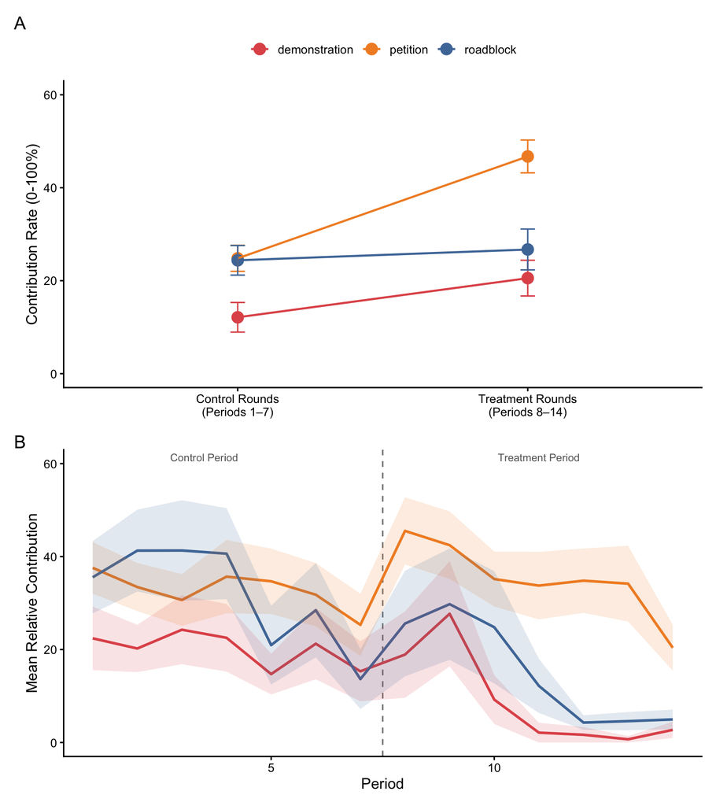

```r
# panel B's legend keys (line + ribbon fill) don't match panel A's (point + line),
# so guides = "collect" places them side by side instead of merging; suppress panel
# B's legend entirely and let panel A's be the one shared legend for the figure
figure1 <- (fig1_panelA / (fig1_panelB + guides(colour = "none", fill = "none"))) +
  plot_annotation(tag_levels = "A") +
  plot_layout(guides = "collect") &
  theme(legend.position = "top")

figure1
```

```r
ggsave(paper_path("figures", "results", "figure1.png"), figure1,
       width = 8, height = 9, dpi = 300, bg = "white")
```

## 4.2 H2: Activism Turnout

**Hypothesis:** Turnout(Roadblock) < Demonstration < Petition

Only available for treatment rounds (>=7) from period t=8 onwards (lagged predictors require t-1 data).

```r
df_activism <- df_long %>%
  filter(
    period >= 8,
    !is.na(chose_activism),
    !is.na(others_contribution_lag),
    !is.na(NegDev_lag),
    !is.na(PosDev_lag)
  )

cat("Observations for activism models:", nrow(df_activism))
```

```
## Observations for activism models: 252
```

TO DO: distribution kinda weird & varied by condition so figure out which model best accounts for this

```r
summary(df_activism$activism_rate)
```

```
##    Min. 1st Qu.  Median    Mean 3rd Qu.    Max.
##     0.0    25.0    75.0    55.2   100.0   100.0
```

```r
table(df_activism$player.chose_activism,df_activism$condition)
```

```
##
##     control petition demonstration roadblock
##   0       0       15            72        26
##   1       0       97            12        30
```

```r
summary(df_activism$num_activists)
```

```
##    Min. 1st Qu.  Median    Mean 3rd Qu.    Max.
##    0.00    1.00    3.00    2.21    4.00    4.00
```

```r
table(df_activism$num_activists,df_activism$condition) #in most cases people didn't demonstrate, a good bit often chose roadblocking
```

```
##
##     control petition demonstration roadblock
##   0       0        0            56         0
##   1       0        4            16        12
##   2       0        4             4        28
##   3       0       40             8        12
##   4       0       64             0         4
```

### 4.2.1 NUMERIC VERSION

```r
#if we use num_activists/activist rate it duplicates for each group member so just use the group level version

#pure - all groups
model_h2_ols <- lm(player.chose_activism * 100 ~ condition + others_contribution_lag + NegDev_lag + PosDev_lag + period,
                   data = df_long)

nice_table((emmeans(model_h2_ols, pairwise ~ condition, adjust = "holm")$emmeans))
```

| condition | emmean | SE | df | 95% CI |
| --- | --- | --- | --- | --- |
| petition | 81.65 | 3.88 | 245 | [74.01, 89.30] |
| demonstration | 18.60 | 4.33 | 245 | [10.07, 27.14] |
| roadblock | 57.01 | 5.15 | 245 | [46.86, 67.15] |

```r
nice_table((emmeans(model_h2_ols, pairwise ~ condition, adjust = "holm")$contrasts))
```

| contrast | estimate | SE | df | t | p |
| --- | --- | --- | --- | --- | --- |
| petition - demonstration | 63.05 | 6.17 | 245 | 10.21 | < .001*** |
| petition - roadblock | 24.65 | 6.70 | 245 | 3.68 | < .001*** |
| demonstration - roadblock | -38.40 | 6.52 | 245 | -5.89 | < .001*** |

```r
# Cluster-robust SEs
coeftest(model_h2_ols, vcov = vcovCL(model_h2_ols, cluster = ~ group_id))
```

```
##
## t test of coefficients:
##
##                         Estimate Std. Error t value       Pr(>|t|)
## (Intercept)              108.011     15.520    6.96 0.000000000031 ***
## conditiondemonstration   -63.048     10.285   -6.13 0.000000003483 ***
## conditionroadblock       -24.646     11.213   -2.20         0.0289 *
## others_contribution_lag    0.356      0.133    2.67         0.0082 **
## NegDev_lag                -0.498      0.362   -1.38         0.1701
## PosDev_lag                 0.152      0.247    0.62         0.5378
## period                    -2.977      1.458   -2.04         0.0422 *
## ---
## Signif. codes:  0 '***' 0.001 '**' 0.01 '*' 0.05 '.' 0.1 ' ' 1
```

```r
# Reference = demonstration, not control (the project default): control has zero
# valid rows for this outcome (no control-period activism turnout to speak of), so a
# control reference leaves the model rank-deficient and R silently drops a different
# dummy instead.
model_h2_ols_rob <- estimatr::lm_robust(player.chose_activism ~ condition + others_contribution_lag + NegDev_lag + PosDev_lag + period,
                   data = df_long %>% mutate(condition = relevel(factor(condition), ref = "demonstration")),
                   clusters = group_id,
                   se_type = "CR2") #because small sample
tab_model(model_h2_ols_rob)
```

|  | player chose activism |  |  |
| --- | --- | --- | --- |
| Predictors | Estimates | CI | p |
| (Intercept) | 0.45 | -0.03 – 0.93 | 0.065 |
| condition [petition] | 0.63 | 0.40 – 0.86 | **<0.001** |
| condition [roadblock] | 0.38 | 0.07 – 0.70 | **0.016** |
| others contribution lag | 0.00 | -0.00 – 0.01 | 0.080 |
| NegDev lag | -0.00 | -0.01 – 0.00 | 0.254 |
| PosDev lag | 0.00 | -0.00 – 0.01 | 0.558 |
| period | -0.03 | -0.06 – -0.00 | **0.043** |
| Observations | 252 |  |  |
| R<sup>2</sup> / R<sup>2</sup> adjusted | 0.444 / 0.431 |  |  |

```r
# Save lagged-controls model for the paper (Table \ref{tab:model_lag})
save_reg_table(list("Activism Turnout" = model_h2_ols_rob),
               path = paper_path("tables", "results", "model_lag.tex"))

# Main-table version: condition + period only, no lagged controls -- matches
# the H1/H3 specification and feeds the "Activism Turnout" column of
# tables/results/mainreg.tex. The lagged specification above is the dedicated
# test of the Fehr (2000) reciprocity hypothesis (Table \ref{tab:model_lag}).
# Reference = demonstration, not control, for the same reason as model_h2_ols_rob above.
model_h2_main_rob <- estimatr::lm_robust(player.chose_activism ~ condition + period,
                   data = df_long %>% mutate(condition = relevel(factor(condition), ref = "demonstration")),
                   clusters = group_id,
                   se_type = "CR2")
tab_model(model_h2_main_rob)
```

|  | player chose activism |  |  |
| --- | --- | --- | --- |
| Predictors | Estimates | CI | p |
| (Intercept) | 0.47 | -0.02 – 0.96 | 0.058 |
| condition [petition] | 0.72 | 0.51 – 0.93 | **<0.001** |
| condition [roadblock] | 0.39 | 0.06 – 0.73 | **0.021** |
| period | -0.03 | -0.06 – 0.00 | 0.058 |
| Observations | 252 |  |  |
| R<sup>2</sup> / R<sup>2</sup> adjusted | 0.417 / 0.410 |  |  |

#### 4.2.1.1 Group-Level Activism Turnout

```r
df_activism_group <- df_long %>%
  filter(is_treatment_round == 1) %>%
  group_by(group_id, period, condition) %>%
  summarise(
    turnout_rate = mean(player.chose_activism, na.rm = TRUE) * 100,
    n_activists  = sum(num_activists, na.rm = TRUE),

    NegDev_lag = mean(NegDev_lag, na.rm = TRUE),
    PosDev_lag = mean(PosDev_lag, na.rm = TRUE), #pos & neg the same when aggregated? it drops posdev
    others_contribution_lag = mean(others_contribution_lag, na.rm = TRUE),

    group_size   = n(),
    .groups      = "drop")

model_h2_group <- estimatr::lm_robust(turnout_rate ~ condition + others_contribution_lag + NegDev_lag + PosDev_lag + period,
                   data = df_activism_group,
                   clusters = group_id,
                   se_type = "CR2") #because small sample

tab_model(model_h2_ols_rob)
```

|  | player chose activism |  |  |
| --- | --- | --- | --- |
| Predictors | Estimates | CI | p |
| (Intercept) | 0.45 | -0.03 – 0.93 | 0.065 |
| condition [petition] | 0.63 | 0.40 – 0.86 | **<0.001** |
| condition [roadblock] | 0.38 | 0.07 – 0.70 | **0.016** |
| others contribution lag | 0.00 | -0.00 – 0.01 | 0.080 |
| NegDev lag | -0.00 | -0.01 – 0.00 | 0.254 |
| PosDev lag | 0.00 | -0.00 – 0.01 | 0.558 |
| period | -0.03 | -0.06 – -0.00 | **0.043** |
| Observations | 252 |  |  |
| R<sup>2</sup> / R<sup>2</sup> adjusted | 0.444 / 0.431 |  |  |

### 4.2.2 BINARY VERSION (Logistic/Main Specification)

```r
model_h2_logit <- glm(player.chose_activism ~ condition + others_contribution_lag + NegDev_lag + PosDev_lag + period,
                      family = binomial(link = "logit"), data = df_activism)
tab_model(model_h2_logit)
```

|  | player chose activism |  |  |
| --- | --- | --- | --- |
| Predictors | Odds Ratios | CI | p |
| (Intercept) | 15.44 | 1.70 – 161.15 | **0.018** |
| condition [demonstration] | 0.04 | 0.02 – 0.11 | **<0.001** |
| condition [roadblock] | 0.34 | 0.15 – 0.80 | **0.014** |
| others contribution lag | 1.05 | 1.02 – 1.09 | **0.003** |
| NegDev lag | 0.93 | 0.88 – 0.98 | **0.014** |
| PosDev lag | 1.00 | 0.98 – 1.04 | 0.758 |
| period | 0.85 | 0.71 – 1.01 | 0.064 |
| Observations | 252 |  |  |
| R<sup>2</sup> Tjur | 0.457 |  |  |

```r
vcov_h2_logit <- vcovCL(model_h2_logit, cluster = ~ group_id)
coeftest(model_h2_logit, vcov = vcov_h2_logit)
```

```
##
## z test of coefficients:
##
##                         Estimate Std. Error z value Pr(>|z|)
## (Intercept)              2.73726    1.18890    2.30  0.02132 *
## conditiondemonstration  -3.11809    0.82515   -3.78  0.00016 ***
## conditionroadblock      -1.06439    0.48660   -2.19  0.02871 *
## others_contribution_lag  0.05056    0.03286    1.54  0.12383
## NegDev_lag              -0.06757    0.04858   -1.39  0.16422
## PosDev_lag               0.00455    0.02082    0.22  0.82719
## period                  -0.16564    0.08831   -1.88  0.06071 .
## ---
## Signif. codes:  0 '***' 0.001 '**' 0.01 '*' 0.05 '.' 0.1 ' ' 1
```

```r
emm_h2_logit <- emmeans(model_h2_logit, "condition", vcov. = vcov_h2_logit)
emm_h2_logit
```

```
##  condition     emmean    SE  df asymp.LCL asymp.UCL
##  petition       1.742 0.318 Inf     1.119     2.366
##  demonstration -1.376 0.828 Inf    -2.999     0.248
##  roadblock      0.678 0.483 Inf    -0.269     1.625
##
## Results are given on the logit (not the response) scale.
## Confidence level used: 0.95
```

### 4.2.3 Probit (Robustness)

```r
model_h2_probit <- glm(player.chose_activism ~ condition + others_contribution_lag +
    NegDev_lag + PosDev_lag + period,
  family = binomial(link = "probit"), data = df_activism)

vcov_h2_probit <- vcovCL(model_h2_probit, cluster = ~ group_id)
coeftest(model_h2_probit, vcov = vcov_h2_probit)
```

```
##
## z test of coefficients:
##
##                         Estimate Std. Error z value Pr(>|z|)
## (Intercept)              1.67859    0.68749    2.44    0.015 *
## conditiondemonstration  -1.84172    0.44616   -4.13 0.000037 ***
## conditionroadblock      -0.63349    0.28845   -2.20    0.028 *
## others_contribution_lag  0.02782    0.01807    1.54    0.124
## NegDev_lag              -0.03699    0.02671   -1.38    0.166
## PosDev_lag               0.00169    0.01185    0.14    0.887
## period                  -0.10130    0.05253   -1.93    0.054 .
## ---
## Signif. codes:  0 '***' 0.001 '**' 0.01 '*' 0.05 '.' 0.1 ' ' 1
```

### 4.2.4 Figs: Turnout

#### 4.2.4.1 2a. Main Effects (Preregistered)

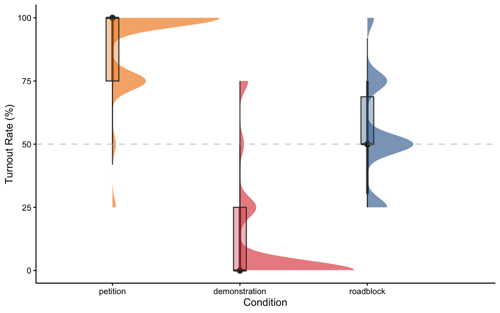

```r
fig_2_1_activismrate <- df_activism_group %>%
  ggplot(aes(x = condition, y = turnout_rate, fill = condition)) +
  ggdist::stat_halfeye(alpha = 0.7, adjust = 0.8) +
  geom_boxplot(width = 0.1, outlier.shape = NA, alpha = 0.4) +
  scale_fill_manual(values = condition_colors) +
  labs(#title = "Activism Turnout Rate by Condition",
       #subtitle = "Treatment rounds only (periods 8–14)",
       x = "Condition", y = "Turnout Rate (%)", fill = NULL) +
  theme_classic(base_size = 12) +
  theme(legend.position = "none") +
  geom_hline(yintercept = 50, colour = "darkgray", alpha = .4, size = 0.8, linetype = "dashed")

fig_2_1_activismrate
```

```r
ggsave(paper_path("figures", "results", "2.1.activismrate.png"), fig_2_1_activismrate,
       width = 8, height = 5, dpi = 300, bg = "white")
```

#### 4.2.4.2 2b. Main Effects (Over Time)

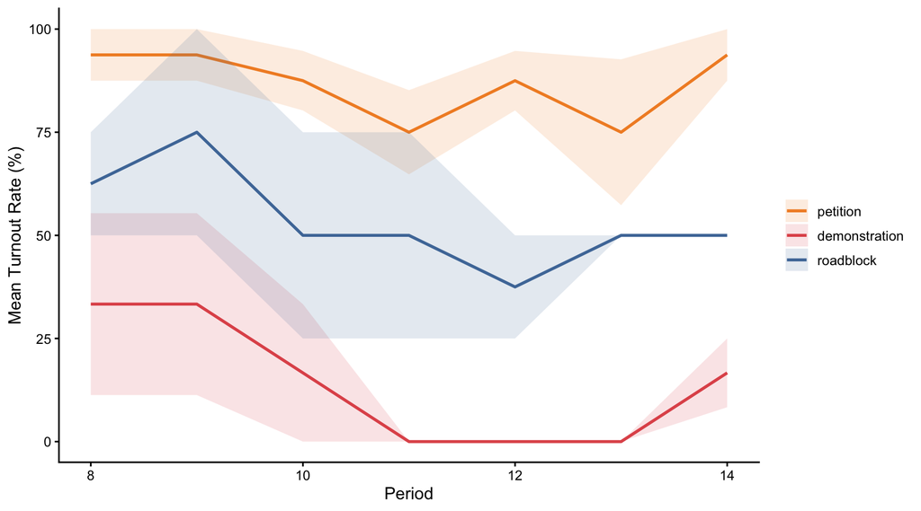

```r
#on group level data
fig_2_1_activismrateovertime <- df_activism_group %>%
  group_by(period, condition) %>%
  summarise(
    mean_turnout = mean(turnout_rate, na.rm = TRUE),
    se_turnout   = sd(turnout_rate, na.rm = TRUE) / sqrt(n()),
    .groups = "drop") %>%
  ggplot(aes(x = period, y = mean_turnout, colour = condition, group = condition)) +
  geom_line(linewidth = 1) +
  geom_ribbon(aes(ymin = mean_turnout - se_turnout, ymax = mean_turnout + se_turnout,
                  fill = condition), alpha = 0.15, colour = NA) +
  scale_colour_manual(values = treatment_colors) +
  scale_fill_manual(values = treatment_colors) +
  labs(#title = "Activism Turnout Rate Over Time",
       #subtitle = "Treatment rounds only (periods 8-14)",
       x = "Period", y = "Mean Turnout Rate (%)", colour = NULL, fill = NULL) +
  theme_classic(base_size = 12) +
  xlim(c(8, 14))

fig_2_1_activismrateovertime
```

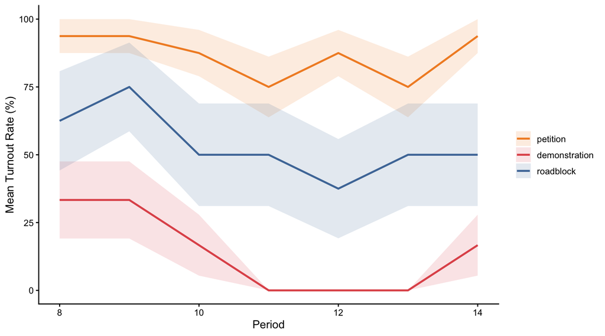

```r
ggsave(paper_path("figures", "results", "2.1.activismrateovertime.png"), fig_2_1_activismrateovertime,
       width = 9, height = 5, dpi = 300, bg = "white")

#on individual-level data
df_long %>%
  group_by(period, condition) %>%
  summarise(
    mean_turnout = mean(player.chose_activism, na.rm = TRUE) *100,
    se_turnout   = sd(player.chose_activism, na.rm = TRUE) / sqrt(n()) * 100,
    .groups = "drop") %>%
  ggplot(aes(x = period, y = mean_turnout, colour = condition, group = condition)) +
  geom_line(linewidth = 1) +
  geom_ribbon(aes(ymin = mean_turnout - se_turnout, ymax = mean_turnout + se_turnout,
                  fill = condition), alpha = 0.15, colour = NA) +
  scale_colour_manual(values = treatment_colors) +
  scale_fill_manual(values = treatment_colors) +
  labs(#title = "Activism Turnout Rate Over Time",
       #subtitle = "Treatment rounds only (periods 8-14)",
       x = "Period", y = "Mean Turnout Rate (%)", colour = NULL, fill = NULL) +
  theme_classic(base_size = 12) +
  xlim(c(8, 14))
```

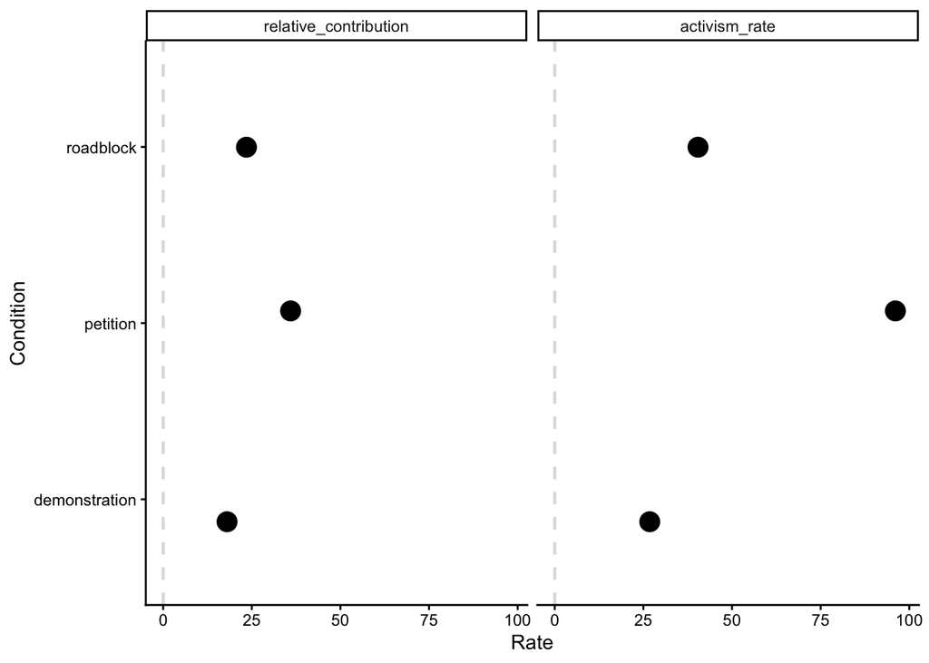

```r
ggerrorplot(df_long,
            x = "treatment_assigned", y = c("relative_contribution","activism_rate"),
            combine = T,
            size = 1,
            add.params = list(),legend = "top",
            position = position_jitter(.2), alpha = .8, orientation =  "horiz", add = "mean_se",
            na.rm = T, sort.val = "asc") +
  geom_hline(yintercept = 0, colour = "darkgray", alpha = .4, size = 0.8, linetype = "dashed") +
  labs(x = "Condition", y = "Rate"#, title = "Contribution & Activism Rate by Condition"
       ) +  # Custom legend title
  theme_classic()  +
  theme(legend.title = element_text(size = 10, face = "bold"))
```

## 4.3 H3: Welfare

**Hypothesis:** Welfare(Roadblock) < Demonstration < Petition

### 4.3.1 Welfare = total group earnings per period.

```r
summary(df_long$welfare)
```

```
##    Min. 1st Qu.  Median    Mean 3rd Qu.    Max.    NA's
##     303     415     459     473     510     772       2
```

```r
model_h3 <- lm(welfare ~ condition + period, data = df_long)
vcov_h3   <- vcovCL(model_h3, cluster = ~ group_id)
coeftest(model_h3, vcov = vcov_h3)
```

```
##
## t test of coefficients:
##
##                        Estimate Std. Error t value            Pr(>|t|)
## (Intercept)              455.45      15.09   30.18 <0.0000000000000002 ***
## conditionpetition         57.52      58.62    0.98               0.327
## conditiondemonstration   -18.61      25.44   -0.73               0.465
## conditionroadblock       -74.54      30.11   -2.48               0.014 *
## period                     2.36       3.10    0.76               0.447
## ---
## Signif. codes:  0 '***' 0.001 '**' 0.01 '*' 0.05 '.' 0.1 ' ' 1
```

```r
nice_table((emmeans(model_h3, pairwise ~ condition, adjust = "holm")$emmeans))
```

| condition | emmean | SE | df | 95% CI |
| --- | --- | --- | --- | --- |
| control | 471.47 | 6.28 | 605 | [459.13, 483.81] |
| petition | 528.99 | 9.99 | 605 | [509.37, 548.60] |
| demonstration | 452.86 | 10.86 | 605 | [431.53, 474.19] |
| roadblock | 396.93 | 12.42 | 605 | [372.53, 421.33] |

```r
nice_table((emmeans(model_h3, pairwise ~ condition, adjust = "holm")$contrasts))
```

| contrast | estimate | SE | df | t | p |
| --- | --- | --- | --- | --- | --- |
| control - petition | -57.52 | 14.24 | 605 | -4.04 | < .001*** |
| control - demonstration | 18.61 | 14.87 | 605 | 1.25 | .211 |
| control - roadblock | 74.54 | 16.04 | 605 | 4.65 | < .001*** |
| petition - demonstration | 76.13 | 11.29 | 605 | 6.75 | < .001*** |
| petition - roadblock | 132.06 | 12.80 | 605 | 10.32 | < .001*** |
| demonstration - roadblock | 55.93 | 13.49 | 605 | 4.15 | < .001*** |

```r
model_h3_ols_rob <- estimatr::lm_robust(welfare ~ condition + period,
                   data = df_long,
                   clusters = group_id,
                   se_type = "CR2") #because small sample
tab_model(model_h3_ols_rob)
```

|  | welfare |  |  |
| --- | --- | --- | --- |
| Predictors | Estimates | CI | p |
| (Intercept) | 455.45 | 425.90 – 485.00 | **<0.001** |
| condition [petition] | 57.52 | -68.20 – 183.23 | 0.369 |
| condition [demonstration] | -18.61 | -68.34 – 31.12 | 0.463 |
| condition [roadblock] | -74.54 | -136.29 – -12.79 | **0.018** |
| period | 2.36 | -3.74 – 8.46 | 0.448 |
| Observations | 610 |  |  |
| R<sup>2</sup> / R<sup>2</sup> adjusted | 0.174 / 0.169 |  |  |

```r
model_h3norm <- lm(norm_welfare ~ condition + period, data = df_long)
vcov_h3norm   <- vcovCL(model_h3norm, cluster = ~ group_id)
coeftest(model_h3norm, vcov = vcov_h3norm)
```

```
##
## t test of coefficients:
##
##                        Estimate Std. Error t value            Pr(>|t|)
## (Intercept)             10.2238     0.3403   30.04 <0.0000000000000002 ***
## conditionpetition        1.4710     1.3106    1.12                0.26
## conditiondemonstration   0.1854     0.6849    0.27                0.79
## conditionroadblock       0.4420     0.6608    0.67                0.50
## period                   0.0256     0.0713    0.36                0.72
## ---
## Signif. codes:  0 '***' 0.001 '**' 0.01 '*' 0.05 '.' 0.1 ' ' 1
```

```r
nice_table((emmeans(model_h3norm, pairwise ~ condition, adjust = "holm")$emmeans))
```

| condition | emmean | SE | df | 95% CI |
| --- | --- | --- | --- | --- |
| control | 10.40 | 0.14 | 605 | [10.11, 10.68] |
| petition | 11.87 | 0.23 | 605 | [11.42, 12.32] |
| demonstration | 10.58 | 0.25 | 605 | [10.09, 11.07] |
| roadblock | 10.84 | 0.28 | 605 | [10.28, 11.40] |

```r
nice_table((emmeans(model_h3norm, pairwise ~ condition, adjust = "holm")$contrasts))
```

| contrast | estimate | SE | df | t | p |
| --- | --- | --- | --- | --- | --- |
| control - petition | -1.47 | 0.33 | 605 | -4.51 | < .001*** |
| control - demonstration | -0.19 | 0.34 | 605 | -0.54 | .814 |
| control - roadblock | -0.44 | 0.37 | 605 | -1.20 | .690 |
| petition - demonstration | 1.29 | 0.26 | 605 | 4.97 | < .001*** |
| petition - roadblock | 1.03 | 0.29 | 605 | 3.51 | .002** |
| demonstration - roadblock | -0.26 | 0.31 | 605 | -0.83 | .814 |

```r
#nothing sig
model_h3norm_ols_rob <- estimatr::lm_robust(norm_welfare ~ condition + period,
                   data = df_long,
                   clusters = group_id,
                   se_type = "CR2") #because small sample
tab_model(model_h3norm_ols_rob)
```

|  | norm welfare |  |  |
| --- | --- | --- | --- |
| Predictors | Estimates | CI | p |
| (Intercept) | 10.22 | 9.56 – 10.89 | **<0.001** |
| condition [petition] | 1.47 | -1.34 – 4.28 | 0.304 |
| condition [demonstration] | 0.19 | -1.20 – 1.57 | 0.792 |
| condition [roadblock] | 0.44 | -0.87 – 1.75 | 0.507 |
| period | 0.03 | -0.11 – 0.17 | 0.720 |
| Observations | 610 |  |  |
| R<sup>2</sup> / R<sup>2</sup> adjusted | 0.109 / 0.103 |  |  |

### 4.3.2 Figs: Welfare

#### 4.3.2.1 3a. Main Effects (Preregistered)

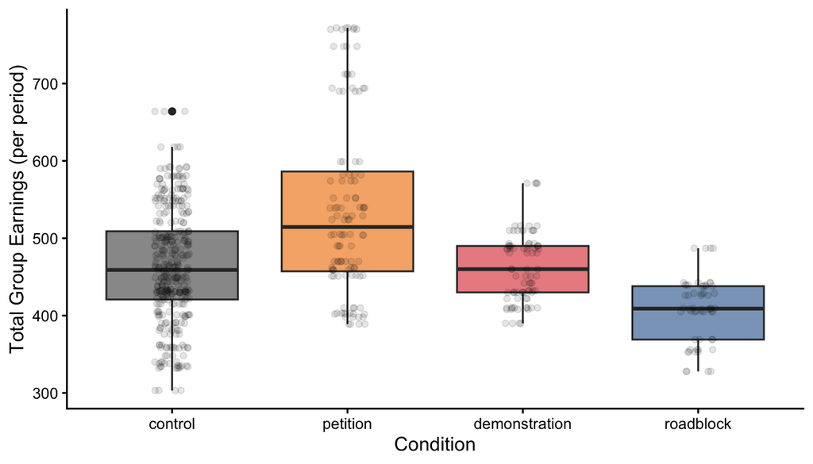

```r
# 1a. by condition
df_long %>%
  filter(!is.na(welfare) & welfare > 0) %>%
  ggplot(aes(x = condition, y = welfare, fill = condition)) +
  geom_boxplot(alpha = 0.7) +
  geom_jitter(width = 0.1, alpha = 0.1, size = 1.5) +
  scale_fill_manual(values = condition_colors) +
  labs(#title = "Group Welfare by Condition",
       x = "Condition", y = "Total Group Earnings (per period)",
       fill = NULL) +
  theme_classic(base_size = 12) +
  theme(legend.position = "none")
```

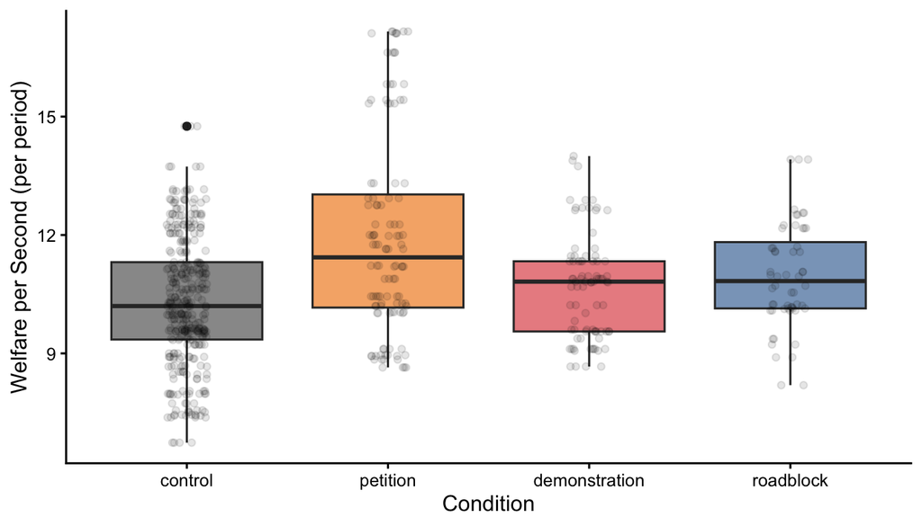

```r
# 1b. normalized welfare
df_long %>%
  filter(!is.na(norm_welfare) & norm_welfare > 0) %>%
  ggplot(aes(x = condition, y = norm_welfare, fill = condition)) +
  geom_boxplot(alpha = 0.7) +
  geom_jitter(width = 0.1, alpha = 0.1, size = 1.5) +
  scale_fill_manual(values = condition_colors) +
  labs(#title = "Group Welfare by Condition (Time-Normalized)",
       x = "Condition", y = "Welfare per Second (per period)",
       fill = NULL) +
  theme_classic(base_size = 12) +
  theme(legend.position = "none")
```

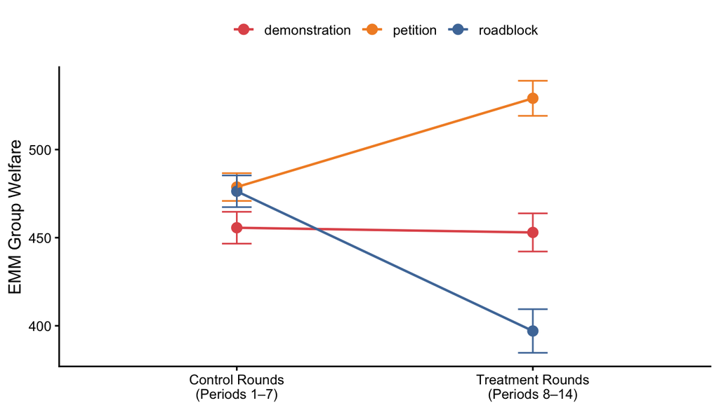

```r
# OLS models mirroring model_h1b_ols structure for phase comparisons
model_h3b_ols     <- lm(welfare      ~ treatment_assigned * is_treatment_round + period,
                         data = df_long %>% filter(!is.na(welfare) & welfare > 0))
model_h3bnorm_ols <- lm(norm_welfare ~ treatment_assigned * is_treatment_round + period,
                         data = df_long %>% filter(!is.na(norm_welfare) & norm_welfare > 0))

# helper: EMMs at both phases + between-group brackets at treatment phase
phase_plot <- function(model, y_label, title_label) {
  emm_ph <- emmeans(model, ~ treatment_assigned * is_treatment_round,
                    at = list(is_treatment_round = c(0, 1))) %>%
    tidy() %>%
    mutate(phase = factor(
      if_else(is_treatment_round == 0, "Control Rounds\n(Periods 1–7)", "Treatment Rounds\n(Periods 8–14)"),
      levels = c("Control Rounds\n(Periods 1–7)", "Treatment Rounds\n(Periods 8–14)")
    ))

  tx_ypos <- emm_ph %>%
    filter(is_treatment_round == 1) %>%
    select(treatment_assigned, estimate) %>%
    deframe()

  brk <- emmeans(model, pairwise ~ treatment_assigned,
                 at = list(is_treatment_round = 1),
                 adjust = "holm")$contrasts %>%
    tidy() %>%
    mutate(
      grp1  = str_trim(str_split_fixed(contrast, " - ", 2)[, 1]),
      grp2  = str_trim(str_split_fixed(contrast, " - ", 2)[, 2]),
      stars = case_when(
        adj.p.value < 0.001 ~ "***",
        adj.p.value < 0.01  ~ "**",
        adj.p.value < 0.05  ~ "*",
        TRUE                ~ "ns"
      )
    ) %>%
    filter(stars != "ns") %>%
    mutate(
      y1    = map_dbl(grp1, ~ tx_ypos[.x]),
      y2    = map_dbl(grp2, ~ tx_ypos[.x]),
      x_off = 2 + row_number() * 0.08
    )

  p <- ggplot(emm_ph, aes(x = phase, y = estimate, colour = treatment_assigned, group = treatment_assigned)) +
    geom_point(size = 3) +
    geom_line(linewidth = 0.8) +
    geom_errorbar(aes(ymin = estimate - std.error, ymax = estimate + std.error), width = 0.1) +
    scale_colour_manual(values = treatment_colors) +
    labs(#title = title_label,
         x = NULL, y = y_label, colour = NULL) +
    theme_classic(base_size = 12) +
    theme(legend.position = "top")

  # significance-star brackets disabled (headers/stars now live in the caption, not the figure)
  if (FALSE && nrow(brk) > 0) {
    p <- p +
      geom_segment(data = brk, aes(x = x_off, xend = x_off, y = y1, yend = y2),
                   inherit.aes = FALSE, colour = "grey40", linewidth = 0.4) +
      geom_segment(data = brk, aes(x = x_off - 0.02, xend = x_off, y = y1, yend = y1),
                   inherit.aes = FALSE, colour = "grey40", linewidth = 0.4) +
      geom_segment(data = brk, aes(x = x_off - 0.02, xend = x_off, y = y2, yend = y2),
                   inherit.aes = FALSE, colour = "grey40", linewidth = 0.4) +
      geom_text(data = brk, aes(x = x_off + 0.04, y = (y1 + y2) / 2, label = stars),
                inherit.aes = FALSE, colour = "grey40", size = 4) +
      coord_cartesian(clip = "off")
  }
  p
}

# raw welfare
fig_3_3_welfareprepost <- phase_plot(model_h3b_ols, "EMM Group Welfare",
           "Group Welfare: Control vs Treatment Rounds by Assigned Condition")
fig_3_3_welfareprepost
```

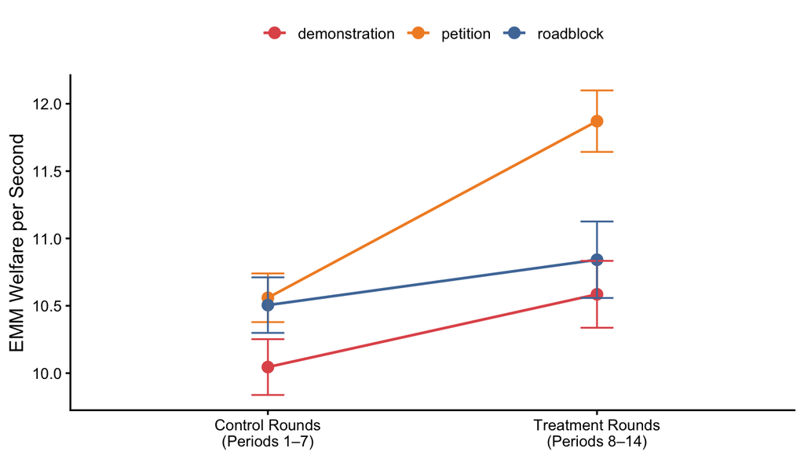

```r
ggsave(paper_path("figures", "results", "3.3.welfareprepost.png"), fig_3_3_welfareprepost,
       width = 7, height = 4, dpi = 300, bg = "white")

# time-normalized welfare
phase_plot(model_h3bnorm_ols, "EMM Welfare per Second",
           "Welfare (Time-Normalized): Control vs Treatment Rounds by Assigned Condition")
```

#### 4.3.2.2 3b. Main Effects (Over Time)

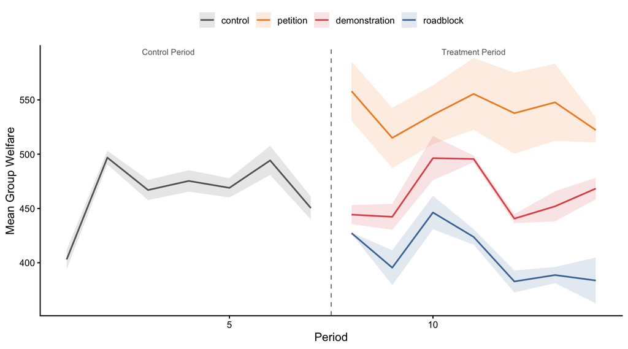

```r
# 3. Welfare over time by condition
df_long %>%
  filter(!is.na(welfare) & welfare > 0) %>%
  group_by(period, condition) %>%
  summarise(
    mean_welfare = mean(welfare, na.rm = TRUE),
    se_welfare   = sd(welfare, na.rm = TRUE) / sqrt(n()),
    .groups = "drop"
  ) %>%
  ggplot(aes(x = period, y = mean_welfare, colour = condition, group = condition)) +
  geom_vline(xintercept = 7.5, linetype = "dashed", colour = "grey50") +
  geom_line(linewidth = 0.8) +
  geom_ribbon(aes(ymin = mean_welfare - se_welfare, ymax = mean_welfare + se_welfare, fill = condition),
              alpha = 0.15, colour = NA) +
  annotate("text", x = 3.5, y = Inf, label = "Control Period", vjust = 1.5,
           colour = "grey40", size = 3) +
  annotate("text", x = 11,  y = Inf, label = "Treatment Period",   vjust = 1.5,
           colour = "grey40", size = 3) +
  scale_colour_manual(values = condition_colors) +
  scale_fill_manual(values = condition_colors) +
  labs(#title = "Group Welfare Over Time by Condition",
       x = "Period", y = "Mean Group Welfare", colour = NULL, fill = NULL) +
  theme_classic(base_size = 12) +
  xlim(c(1, 14))  +
    theme(legend.position = "top")
```

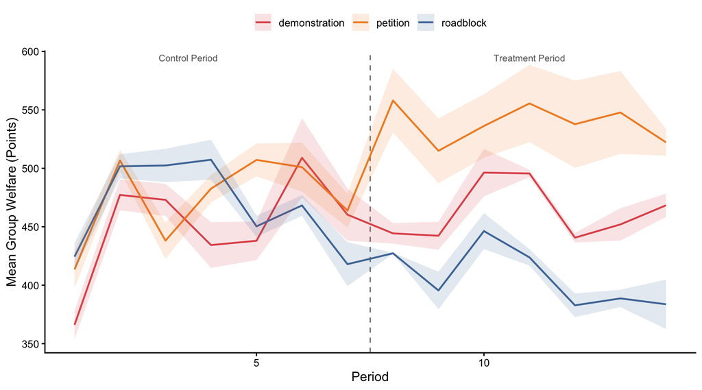

```r
# 4. Welfare over time by treatment_assigned
df_long %>%
  filter(!is.na(welfare) & welfare > 0) %>%
  group_by(period, treatment_assigned) %>%
  summarise(
    mean_welfare = mean(welfare, na.rm = TRUE),
    se_welfare   = sd(welfare, na.rm = TRUE) / sqrt(n()),
    .groups = "drop"
  ) %>%
  ggplot(aes(x = period, y = mean_welfare, colour = treatment_assigned, group = treatment_assigned)) +
  geom_vline(xintercept = 7.5, linetype = "dashed", colour = "grey50") +
  geom_line(linewidth = 0.8) +
  geom_ribbon(aes(ymin = mean_welfare - se_welfare, ymax = mean_welfare + se_welfare, fill = treatment_assigned),
              alpha = 0.15, colour = NA) +
  annotate("text", x = 3.5, y = Inf, label = "Control Period", vjust = 1.5,
           colour = "grey40", size = 3) +
  annotate("text", x = 11,  y = Inf, label = "Treatment Period",   vjust = 1.5,
           colour = "grey40", size = 3) +
  scale_colour_manual(values = treatment_colors) +
  scale_fill_manual(values = treatment_colors) +
  labs(#title = "Group Welfare Over Time by Assigned Condition",
       x = "Period", y = "Mean Group Welfare (Points)", colour = NULL, fill = NULL) +
  theme_classic(base_size = 12) +
  xlim(c(1, 14)) +
    theme(legend.position = "top")
```

# 5 Exploratory Analysis

## 5.1 Efficiency

Efficiency = total group payoff / potential payoff under full cooperation.

```r
summary(df_long$efficiency)
```

```
##    Min. 1st Qu.  Median    Mean 3rd Qu.    Max.    NA's
##    49.1    65.2    69.9    72.0    77.9    92.8       2
```

```r
summary(df_long$welfare)
```

```
##    Min. 1st Qu.  Median    Mean 3rd Qu.    Max.    NA's
##     303     415     459     473     510     772       2
```

```r
summary(df_long$welfare_fullcoop)
```

```
##    Min. 1st Qu.  Median    Mean 3rd Qu.    Max.    NA's
##     400     592     656     658     720     864       2
```

```r
model_efficiency <- lm(efficiency ~ condition + period, data = df_long)
vcov_efficiency  <- vcovCL(model_efficiency, cluster = ~ group_id)
coeftest(model_efficiency, vcov = vcov_efficiency)
```

```
##
## t test of coefficients:
##
##                        Estimate Std. Error t value            Pr(>|t|)
## (Intercept)              77.134      2.118   36.42 <0.0000000000000002 ***
## conditionpetition        10.504      3.712    2.83              0.0048 **
## conditiondemonstration    0.557      2.997    0.19              0.8525
## conditionroadblock        3.646      4.816    0.76              0.4493
## period                   -1.101      0.294   -3.75              0.0002 ***
## ---
## Signif. codes:  0 '***' 0.001 '**' 0.01 '*' 0.05 '.' 0.1 ' ' 1
```

```r
# Cluster-robust version (CR2), matching the other mainreg models -- feeds the
# "Efficiency" column of tables/results/mainreg.tex
model_efficiency_rob <- estimatr::lm_robust(efficiency ~ condition + period,
                   data = df_long,
                   clusters = group_id,
                   se_type = "CR2")
tab_model(model_efficiency_rob)
```

|  | efficiency |  |  |
| --- | --- | --- | --- |
| Predictors | Estimates | CI | p |
| (Intercept) | 77.13 | 72.98 – 81.29 | **<0.001** |
| condition [petition] | 10.50 | 2.63 – 18.38 | **0.009** |
| condition [demonstration] | 0.56 | -5.51 – 6.63 | 0.857 |
| condition [roadblock] | 3.65 | -7.70 – 14.99 | 0.528 |
| period | -1.10 | -1.68 – -0.52 | **<0.001** |
| Observations | 610 |  |  |
| R<sup>2</sup> / R<sup>2</sup> adjusted | 0.217 / 0.212 |  |  |

```r
model_efficiency_emm <- emmeans(model_efficiency, pairwise ~ condition, adjust = "holm")

nice_table((emmeans(model_efficiency, pairwise ~ condition, adjust = "holm")$emmeans))
```

| condition | emmean | SE | df | 95% CI |
| --- | --- | --- | --- | --- |
| control | 69.66 | 0.58 | 605 | [68.52, 70.80] |
| petition | 80.16 | 0.92 | 605 | [78.36, 81.97] |
| demonstration | 70.22 | 1.00 | 605 | [68.25, 72.18] |
| roadblock | 73.31 | 1.15 | 605 | [71.06, 75.55] |

```r
nice_table((emmeans(model_efficiency, pairwise ~ condition, adjust = "holm")$contrasts))
```

| contrast | estimate | SE | df | t | p |
| --- | --- | --- | --- | --- | --- |
| control - petition | -10.50 | 1.31 | 605 | -8.00 | < .001*** |
| control - demonstration | -0.56 | 1.37 | 605 | -0.41 | .684 |
| control - roadblock | -3.65 | 1.48 | 605 | -2.47 | .040* |
| petition - demonstration | 9.95 | 1.04 | 605 | 9.56 | < .001*** |
| petition - roadblock | 6.86 | 1.18 | 605 | 5.81 | < .001*** |
| demonstration - roadblock | -3.09 | 1.24 | 605 | -2.48 | .040* |

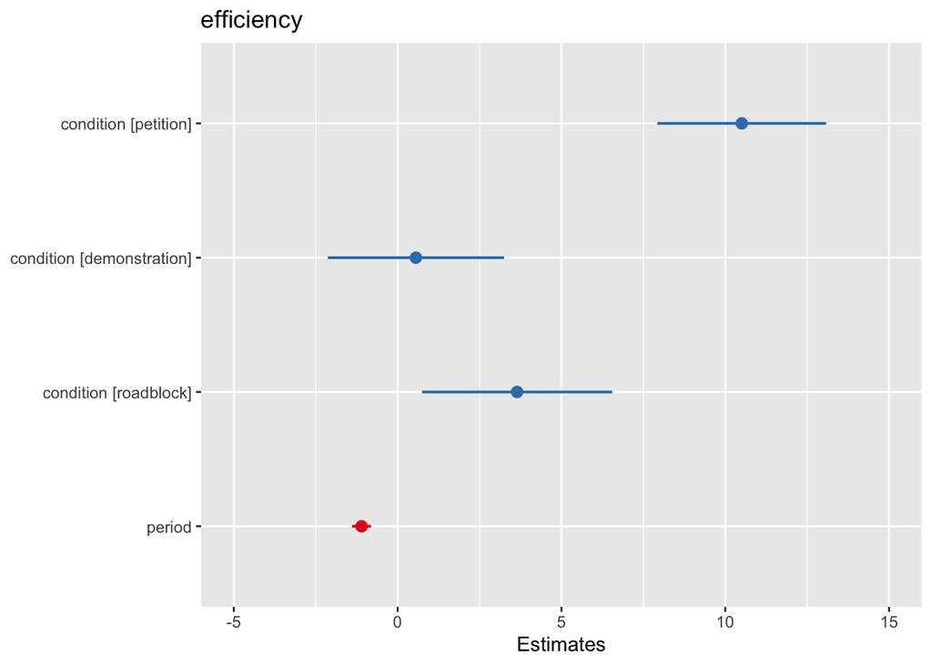

```r
plot_model(model_efficiency)
```

#### 5.1.0.1 4. Fig: Efficiency

```r
model_efficiency_emm$contrasts
```

```
##  contrast                  estimate   SE  df t.ratio p.value
##  control - petition         -10.504 1.31 605  -8.003 <0.0001
##  control - demonstration     -0.557 1.37 605  -0.407  0.6843
##  control - roadblock         -3.646 1.48 605  -2.466  0.0397
##  petition - demonstration     9.947 1.04 605   9.563 <0.0001
##  petition - roadblock         6.858 1.18 605   5.815 <0.0001
##  demonstration - roadblock   -3.089 1.24 605  -2.484  0.0397
##
## P value adjustment: holm method for 6 tests
```

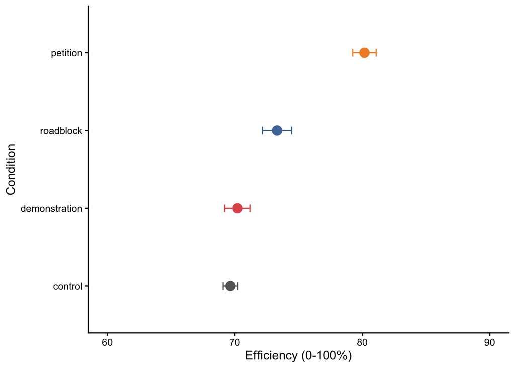

```r
# control-only comparisons (Holm-adjusted)
emm_eff_vals <- tidy(model_efficiency_emm$emmeans) %>% select(condition, emm_est = estimate)

sig_eff <- tidy(model_efficiency_emm$contrasts) %>%
  mutate(
    grp1  = str_trim(str_split_fixed(contrast, " - ", 2)[, 1]),
    grp2  = str_trim(str_split_fixed(contrast, " - ", 2)[, 2]),
    stars = case_when(
      adj.p.value < 0.001 ~ "***",
      adj.p.value < 0.01  ~ "**",
      adj.p.value < 0.05  ~ "*",
      TRUE                ~ "ns"
    )
  ) %>%
  filter(stars != "ns", grp1 == "control" | grp2 == "control") %>%
  left_join(emm_eff_vals, by = c("grp1" = "condition")) %>% rename(e1 = emm_est) %>%
  left_join(emm_eff_vals, by = c("grp2" = "condition")) %>% rename(e2 = emm_est) %>%
  mutate(y_pos = pmax(e1, e2) + 2 + (row_number() - 1) * 3)

fig_5_efficiency <- ggplot(tidy(model_efficiency_emm$emmeans), aes(x = reorder(condition, estimate), y = estimate, colour = condition)) +
  geom_point(size = 4) +
  geom_errorbar(aes(ymin = estimate - std.error, ymax = estimate + std.error), width = 0.1) +
  #geom_signif(
  #  comparisons  = map2(sig_eff$grp1, sig_eff$grp2, ~ c(.x, .y)),
  #  annotations  = sig_eff$stars,
  #  y_position   = sig_eff$y_pos,
  #  tip_length   = 0.01,
  #  vjust        = -0.2,
  #  colour       = "darkgray") +
  scale_colour_manual(values = condition_colors) +
  labs(#title = "Estimated Marginal Means: Efficiency by Condition",
       #subtitle = "OLS with cluster-robust SEs (relative to control)",
       x = "Condition", y = "Efficiency (0-100%)",
       colour = NULL) +
  theme_classic(base_size = 12) +
  theme(legend.position = "none") +
  coord_flip() +
  ylim(c(60, 90))

fig_5_efficiency
```

```r
ggsave(paper_path("figures", "results", "5.efficiency.png"), fig_5_efficiency,
       width = 7, height = 5, dpi = 300, bg = "white")
```

## 5.2 Activist vs. Non-Activist Contributions

```r
#interesting cuz activists earned less on avg (not as good at RET typically) & contributed more but got closer to non-activist income levels (esp in petition condition) - are they really prosocial or just disadvantaged - or is


df_long %>%
  dplyr::filter(is_treatment_round == 1) %>%
  dplyr::mutate(activist = factor(player.chose_activism, labels = c("Non-Activist", "Activist"))) %>%
  dplyr::group_by(condition, player.chose_activism) %>%
  dplyr::summarise(n = n(),
    "Wage" = mean(wage, na.rm = TRUE),
    "Norm Wage" = mean(wage, na.rm = TRUE) / mean(actual_effort_time, na.rm = TRUE),

    'Avg Contribution %' = mean(relative_contribution, na.rm = TRUE),
    "Contribution % (SD)" = sd(relative_contribution, na.rm = TRUE),
    "Contribution" = mean(contribution, na.rm = TRUE),

    "Avg Payoff" = mean(round_payoff, na.rm = TRUE),
    "Avg Added Wage" = mean(round_payoff, na.rm = TRUE) - mean(wage, na.rm = TRUE),
    .groups = "drop") %>%
  kbl(digits = 2, caption = "Contribution Rate: Activists vs. Non-activists") %>%
  kable_styling(bootstrap_options = c("striped", "hover"), full_width = FALSE)
```

Contribution Rate: Activists vs. Non-activists

| condition | player.chose_activism | n | Wage | Norm Wage | Avg Contribution % | Contribution % (SD) | Contribution | Avg Payoff | Avg Added Wage |
| --- | --- | --- | --- | --- | --- | --- | --- | --- | --- |
| petition | 0 | 15 | 118.00 | 2.62 | 7.74 | 15.10 | 6.67 | 141.60 | 23.60 |
| petition | 1 | 97 | 110.10 | 2.45 | 39.43 | 26.90 | 44.33 | 133.67 | 23.57 |
| demonstration | 0 | 72 | 116.11 | 2.58 | 4.23 | 12.20 | 4.76 | 120.80 | 4.69 |
| demonstration | 1 | 12 | 78.33 | 2.24 | 37.65 | 41.83 | 29.58 | 85.08 | 6.75 |
| roadblock | 0 | 26 | 111.54 | 2.79 | 3.73 | 8.04 | 3.92 | 121.11 | 9.57 |
| roadblock | 1 | 30 | 77.67 | 2.22 | 25.09 | 28.81 | 22.50 | 84.91 | 7.25 |

```r
summary(df_long$player.chose_activism)
```

```
##    Min. 1st Qu.  Median    Mean 3rd Qu.    Max.    NA's
##   0.000   0.000   1.000   0.552   1.000   1.000     360
```

```r
model_activist <-estimatr::lm_robust(relative_contribution ~ condition * (player.chose_activism) + period,
                   data = df_long,
                   clusters = group_id,
                   se_type = "CR2")
tab_model(model_activist)
```

|  | relative contribution |  |  |
| --- | --- | --- | --- |
| Predictors | Estimates | CI | p |
| (Intercept) | 42.39 | 15.31 – 69.46 | **0.002** |
| condition [demonstration] | -4.04 | -22.07 – 13.98 | 0.659 |
| condition [roadblock] | -4.29 | -21.56 – 12.99 | 0.625 |
| player chose activism | 30.29 | 7.49 – 53.09 | **0.009** |
| period | -3.04 | -4.62 – -1.46 | **<0.001** |
| condition [demonstration] × player chose activism | -1.61 | -25.00 – 21.78 | 0.892 |
| condition [roadblock] × player chose activism | -10.68 | -37.10 – 15.74 | 0.427 |
| Observations | 252 |  |  |
| R<sup>2</sup> / R<sup>2</sup> adjusted | 0.390 / 0.375 |  |  |

##### 5.2.0.0.1 5. Fig: Activism Choice & Contribution

```r
#can't run meaningful model here because a lot of people didn't choose activism in some conditions; in RB always at least 1 activist
hactiv.lmer <- lmer(relative_contribution ~ treatment_assigned * player.chose_activism + period + (1 | group_id) + (1 | participant.code),
           data = df_long)
tab_model(hactiv.lmer)
```

|  | relative contribution |  |  |
| --- | --- | --- | --- |
| Predictors | Estimates | CI | p |
| (Intercept) | 37.49 | 16.61 – 58.36 | **<0.001** |
| treatment assigned [petition] | 10.76 | -13.61 – 35.13 | 0.385 |
| treatment assigned [roadblock] | -1.46 | -28.85 – 25.93 | 0.916 |
| player chose activism | 32.01 | 19.98 – 44.05 | **<0.001** |
| period | -3.00 | -4.08 – -1.92 | **<0.001** |
| treatment assigned [petition] × player chose activism | -8.93 | -25.26 – 7.40 | 0.283 |
| treatment assigned [roadblock] × player chose activism | -9.24 | -25.64 – 7.16 | 0.268 |
| Random Effects |  |  |  |
| σ<sup>2</sup> | 289.96 |  |  |
| τ<sub>00</sub> <sub>participant.code</sub> | 75.26 |  |  |
| τ<sub>00</sub> <sub>group_id</sub> | 190.62 |  |  |
| ICC | 0.48 |  |  |
| N <sub>group_id</sub> | 9 |  |  |
| N <sub>participant.code</sub> | 36 |  |  |
| Observations | 252 |  |  |
| Marginal R<sup>2</sup> / Conditional R<sup>2</sup> | 0.350 / 0.661 |  |  |

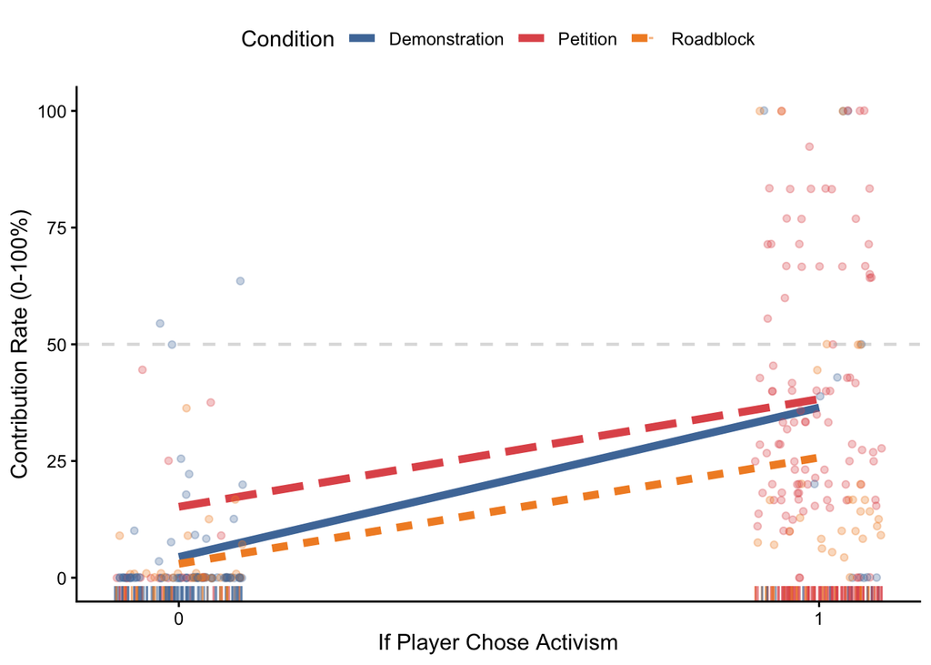

```r
fig_4_activism_cont <- interact_plot(hactiv.lmer, modx = treatment_assigned, pred = player.chose_activism,
              modx.labels = c("Demonstration", "Petition", "Roadblock"),
              legend.main = "Condition",
              plot.points = T, rug = T, jitter = .1, linearity.check = FALSE, point.alpha = .3,
              #interval = T,
              robust = T, line.thickness = 2, int.type = "confidence",
              colors = c("#4E79A7FF", "#E15759FF","#F28E2BFF")) +
  labs(#title = "Interaction Effects: Contribution Rates & Activism Decision",
       x = "If Player Chose Activism", y = "Contribution Rate (0-100%)",
       colour = "Condition") +
  theme_classic(base_size = 12) +
  theme(legend.position = "top") +
  geom_hline(yintercept = 50, colour = "darkgray", alpha = .4, size = 0.8, linetype = "dashed")

fig_4_activism_cont
```

```r
ggsave(paper_path("figures", "results", "4.activism&cont.png"), fig_4_activism_cont,
       width = 7, height = 5, dpi = 300, bg = "white")
```

## 5.3 H1-3: Linear Mixed Effects Models for all Outcomes

### 5.3.1 Main Effects Model

```r
h1.lmer <- lmer(relative_contribution ~ condition + period + (1 | group_id) + (1 | participant.code),
           data = df_long)
summary(h1.lmer)
```

```
## Linear mixed model fit by REML. t-tests use Satterthwaite's method [
## lmerModLmerTest]
## Formula: relative_contribution ~ condition + period + (1 | group_id) +
##     (1 | participant.code)
##    Data: df_long
##
## REML criterion at convergence: 5540
##
## Scaled residuals:
##    Min     1Q Median     3Q    Max
## -3.275 -0.466 -0.063  0.383  4.217
##
## Random effects:
##  Groups           Name        Variance Std.Dev.
##  participant.code (Intercept) 286      16.9
##  group_id         (Intercept) 193      13.9
##  Residual                     418      20.4
## Number of obs: 612, groups:  participant.code, 56; group_id, 14
##
## Fixed effects:
##                        Estimate Std. Error      df t value       Pr(>|t|)
## (Intercept)              39.483      4.753  16.781    8.31 0.000000239340 ***
## conditionpetition        27.401      4.016 556.629    6.82 0.000000000023 ***
## conditiondemonstration    5.600      4.307 558.328    1.30          0.194
## conditionroadblock       15.980      4.837 560.174    3.30          0.001 **
## period                   -2.742      0.423 552.126   -6.48 0.000000000201 ***
## ---
## Signif. codes:  0 '***' 0.001 '**' 0.01 '*' 0.05 '.' 0.1 ' ' 1
##
## Correlation of Fixed Effects:
##             (Intr) cndtnp cndtnd cndtnr
## conditnpttn  0.189
## cndtndmnstr  0.176  0.513
## cndtnrdblck  0.157  0.456  0.426
## period      -0.332 -0.739 -0.689 -0.614
```

```r
h2.lmer <- lmer(player.chose_activism * 100 ~ condition + others_contribution_lag + NegDev_lag + PosDev_lag + period + (1 | group_id) + (1 | participant.code),
           data = df_long)
summary(h2.lmer)
```

```
## Linear mixed model fit by REML. t-tests use Satterthwaite's method [
## lmerModLmerTest]
## Formula: player.chose_activism * 100 ~ condition + others_contribution_lag +
##     NegDev_lag + PosDev_lag + period + (1 | group_id) + (1 |
##     participant.code)
##    Data: df_long
##
## REML criterion at convergence: 2476
##
## Scaled residuals:
##     Min      1Q  Median      3Q     Max
## -2.8824 -0.3415  0.0131  0.3803  3.0874
##
## Random effects:
##  Groups           Name        Variance Std.Dev.
##  participant.code (Intercept) 505.1    22.47
##  group_id         (Intercept)   7.4     2.72
##  Residual                     942.6    30.70
## Number of obs: 252, groups:  participant.code, 36; group_id, 9
##
## Fixed effects:
##                         Estimate Std. Error      df t value       Pr(>|t|)
## (Intercept)              106.900     14.220  78.769    7.52 0.000000000077 ***
## conditiondemonstration   -64.648     10.472   6.891   -6.17        0.00049 ***
## conditionroadblock       -26.430     11.632   6.506   -2.27        0.06010 .
## others_contribution_lag    0.279      0.133  68.906    2.10        0.03946 *
## NegDev_lag                -0.324      0.273 226.976   -1.19        0.23584
## PosDev_lag                 0.264      0.182 231.711    1.45        0.14896
## period                    -2.776      1.020 215.571   -2.72        0.00702 **
## ---
## Signif. codes:  0 '***' 0.001 '**' 0.01 '*' 0.05 '.' 0.1 ' ' 1
##
## Correlation of Fixed Effects:
##             (Intr) cndtnd cndtnr othr__ NgDv_l PsDv_l
## cndtndmnstr -0.392
## cndtnrdblck -0.326  0.431
## othrs_cntr_ -0.265  0.326  0.269
## NegDev_lag  -0.167 -0.119 -0.133 -0.505
## PosDev_lag  -0.276  0.013 -0.025 -0.103  0.328
## period      -0.830  0.011 -0.006 -0.026  0.249  0.241
```

```r
h3.lmer <- lmer(welfare ~ condition + period + (1 | group_id) + (1 | participant.code),
           data = df_long)
summary(h3.lmer)
```

```
## Linear mixed model fit by REML. t-tests use Satterthwaite's method [
## lmerModLmerTest]
## Formula: welfare ~ condition + period + (1 | group_id) + (1 | participant.code)
##    Data: df_long
##
## REML criterion at convergence: 6585
##
## Scaled residuals:
##    Min     1Q Median     3Q    Max
## -3.651 -0.554 -0.018  0.647  3.040
##
## Random effects:
##  Groups           Name        Variance Std.Dev.
##  participant.code (Intercept)    0      0.0
##  group_id         (Intercept) 3269     57.2
##  Residual                     2759     52.5
## Number of obs: 610, groups:  participant.code, 56; group_id, 14
##
## Fixed effects:
##                        Estimate Std. Error     df t value          Pr(>|t|)
## (Intercept)              455.19      16.06  15.22   28.34 0.000000000000014 ***
## conditionpetition         59.55      10.34 596.88    5.76 0.000000013668256 ***
## conditiondemonstration    -1.05      11.10 598.11   -0.09           0.92451
## conditionroadblock       -46.88      12.47 599.64   -3.76           0.00019 ***
## period                     1.88       1.09 594.17    1.72           0.08547 .
## ---
## Signif. codes:  0 '***' 0.001 '**' 0.01 '*' 0.05 '.' 0.1 ' ' 1
##
## Correlation of Fixed Effects:
##             (Intr) cndtnp cndtnd cndtnr
## conditnpttn  0.143
## cndtndmnstr  0.133  0.509
## cndtnrdblck  0.118  0.453  0.422
## period      -0.251 -0.738 -0.688 -0.612
## optimizer (nloptwrap) convergence code: 0 (OK)
## boundary (singular) fit: see help('isSingular')
```

```r
h3b.lmer <- lmer(norm_welfare ~ condition + period + (1 | group_id) + (1 | participant.code),
           data = df_long)
summary(h3b.lmer)
```

```
## Linear mixed model fit by REML. t-tests use Satterthwaite's method [
## lmerModLmerTest]
## Formula:
## norm_welfare ~ condition + period + (1 | group_id) + (1 | participant.code)
##    Data: df_long
##
## REML criterion at convergence: 2062
##
## Scaled residuals:
##    Min     1Q Median     3Q    Max
## -3.397 -0.652 -0.077  0.648  2.955
##
## Random effects:
##  Groups           Name        Variance Std.Dev.
##  participant.code (Intercept) 0.00     0.00
##  group_id         (Intercept) 1.61     1.27
##  Residual                     1.57     1.25
## Number of obs: 610, groups:  participant.code, 56; group_id, 14
##
## Fixed effects:
##                        Estimate Std. Error       df t value           Pr(>|t|)
## (Intercept)             10.2181     0.3594  15.5520   28.43 0.0000000000000079
## conditionpetition        1.5173     0.2463 597.4801    6.16 0.0000000013354749
## conditiondemonstration   0.5753     0.2642 598.8298    2.18            0.02987
## conditionroadblock       1.0553     0.2969 600.4751    3.55            0.00041
## period                   0.0141     0.0259 594.4394    0.54            0.58793
##
## (Intercept)            ***
## conditionpetition      ***
## conditiondemonstration *
## conditionroadblock     ***
## period
## ---
## Signif. codes:  0 '***' 0.001 '**' 0.01 '*' 0.05 '.' 0.1 ' ' 1
##
## Correlation of Fixed Effects:
##             (Intr) cndtnp cndtnd cndtnr
## conditnpttn  0.152
## cndtndmnstr  0.142  0.510
## cndtnrdblck  0.126  0.454  0.423
## period      -0.268 -0.738 -0.688 -0.612
## optimizer (nloptwrap) convergence code: 0 (OK)
## boundary (singular) fit: see help('isSingular')
```

```r
library(performance)
icc(h1.lmer)
```

```
## # Intraclass Correlation Coefficient
##
##     Adjusted ICC: 0.534
##   Unadjusted ICC: 0.496
```

```r
library(corrplot)
correls <- cor(scale(df_long %>% dplyr::select(wage,contribution,relative_contribution,
                                               player.chose_activism,welfare,norm_welfare,added_wage)),
    use = "complete.obs")
correls
```

```
##                           wage contribution relative_contribution
## wage                   1.00000       0.1725              -0.03264
## contribution           0.17249       1.0000               0.95439
## relative_contribution -0.03264       0.9544               1.00000
## player.chose_activism -0.26645       0.5173               0.56447
## welfare                0.45378       0.6241               0.49804
## norm_welfare           0.27585       0.6451               0.55039
## added_wage            -0.04716       0.1054               0.08970
##                       player.chose_activism welfare norm_welfare added_wage
## wage                                -0.2664  0.4538       0.2759   -0.04716
## contribution                         0.5173  0.6241       0.6451    0.10542
## relative_contribution                0.5645  0.4980       0.5504    0.08970
## player.chose_activism                1.0000  0.2450       0.3916    0.21022
## welfare                              0.2450  1.0000       0.8911    0.49676
## norm_welfare                         0.3916  0.8911       1.0000    0.46116
## added_wage                           0.2102  0.4968       0.4612    1.00000
```

```r
tab_corr(correls,show.p = TRUE,p.numeric = T)
```

|  | wage | contribution | relative_contribution | player.chose_activism | welfare | norm_welfare | added_wage |
| --- | --- | --- | --- | --- | --- | --- | --- |
| wage |  | 0.172 | -0.033 | -0.266 | 0.454 | 0.276 | -0.047 |
| contribution | 0.172 |  | 0.954 | 0.517 | 0.624 | 0.645 | 0.105 |
| relative_contribution | -0.033 | 0.954 |  | 0.564 | 0.498 | 0.550 | 0.090 |
| player.chose_activism | -0.266 | 0.517 | 0.564 |  | 0.245 | 0.392 | 0.210 |
| welfare | 0.454 | 0.624 | 0.498 | 0.245 |  | 0.891 | 0.497 |
| norm_welfare | 0.276 | 0.645 | 0.550 | 0.392 | 0.891 |  | 0.461 |
| added_wage | -0.047 | 0.105 | 0.090 | 0.210 | 0.497 | 0.461 |  |
| Computed correlation used pearson-method with listwise-deletion. |  |  |  |  |  |  |  |

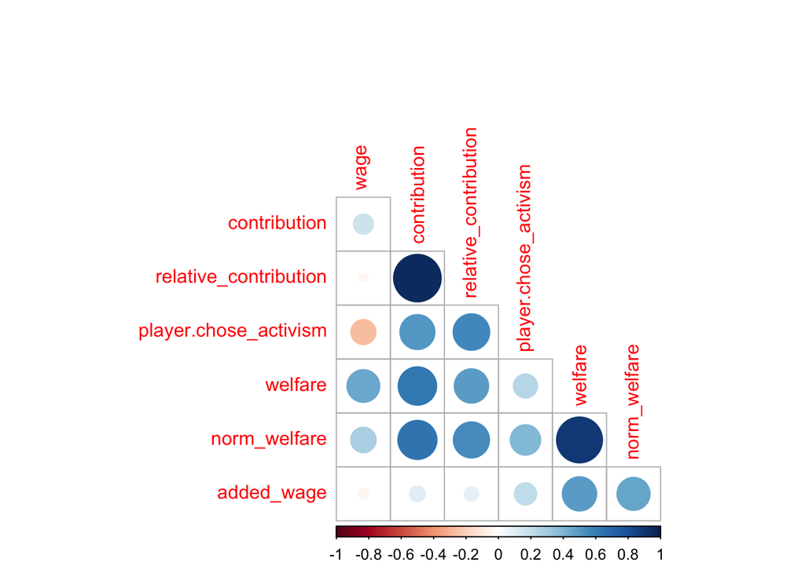

```r
corrplot(correls,type = 'lower',diag = F)
```

### 5.3.2 Interaction Models (Primary)

```r
df_long %>%
  group_by(treatment_assigned,is_treatment_round) %>%
  summarise(mean_contrib = mean(relative_contribution),
            n = n()/4)
```

```
## # A tibble: 6 × 4
## # Groups:   treatment_assigned [3]
##   treatment_assigned is_treatment_round mean_contrib     n
##   <fct>                           <dbl>        <dbl> <dbl>
## 1 demonstration                       0        20.2     26
## 2 demonstration                       1         9.01    21
## 3 petition                            0        32.8     38
## 4 petition                            1        35.2     28
## 5 roadblock                           0        32.5     26
## 6 roadblock                           1        15.2     14
```

```r
#1. CONTRIBUTION RATE
h1.1.lmer <- lmer(relative_contribution ~ treatment_assigned * is_treatment_round + period +
                    (1 | group_id) + (1 | participant.code),
           data = df_long)
summary(h1.1.lmer)
```

```
## Linear mixed model fit by REML. t-tests use Satterthwaite's method [
## lmerModLmerTest]
## Formula: relative_contribution ~ treatment_assigned * is_treatment_round +
##     period + (1 | group_id) + (1 | participant.code)
##    Data: df_long
##
## REML criterion at convergence: 5525
##
## Scaled residuals:
##    Min     1Q Median     3Q    Max
## -3.293 -0.465 -0.063  0.396  4.218
##
## Random effects:
##  Groups           Name        Variance Std.Dev.
##  participant.code (Intercept) 286      16.9
##  group_id         (Intercept) 198      14.1
##  Residual                     418      20.4
## Number of obs: 612, groups:  participant.code, 56; group_id, 14
##
## Fixed effects:
##                                                Estimate Std. Error      df
## (Intercept)                                      29.971      8.596  12.065
## treatment_assignedpetition                       12.700     10.919  11.304
## treatment_assignedroadblock                      14.258     11.947  11.256
## is_treatment_round                                6.100      4.324 552.249
## period                                           -2.742      0.423 552.059
## treatment_assignedpetition:is_treatment_round    21.130      4.158 555.776
## treatment_assignedroadblock:is_treatment_round    9.635      4.962 557.739
##                                                t value     Pr(>|t|)
## (Intercept)                                       3.49       0.0045 **
## treatment_assignedpetition                        1.16       0.2687
## treatment_assignedroadblock                       1.19       0.2572
## is_treatment_round                                1.41       0.1588
## period                                           -6.48 0.0000000002 ***
## treatment_assignedpetition:is_treatment_round     5.08 0.0000005118 ***
## treatment_assignedroadblock:is_treatment_round    1.94       0.0527 .
## ---
## Signif. codes:  0 '***' 0.001 '**' 0.01 '*' 0.05 '.' 0.1 ' ' 1
##
## Correlation of Fixed Effects:
##                  (Intr) trtmnt_ssgndp trtmnt_ssgndr is_tr_ period
## trtmnt_ssgndp    -0.761
## trtmnt_ssgndr    -0.695  0.547
## is_trtmnt_r       0.026  0.078         0.073
## period           -0.185  0.003         0.000        -0.686
## trtmnt_ssgndp:__  0.105 -0.138        -0.076        -0.550  0.000
## trtmnt_ssgndr:__  0.088 -0.069        -0.127        -0.461  0.000
##                  trtmnt_ssgndp:__
## trtmnt_ssgndp
## trtmnt_ssgndr
## is_trtmnt_r
## period
## trtmnt_ssgndp:__
## trtmnt_ssgndr:__  0.479
```

```r
emmeans(h1.1.lmer, pairwise ~ treatment_assigned,
                         at = list(is_treatment_round = 1), adjust = "holm")$contrasts
```

```
##  contrast                  estimate   SE   df t.ratio p.value
##  demonstration - petition    -33.83 11.1 12.2  -3.037  0.0305
##  demonstration - roadblock   -23.89 12.3 12.8  -1.935  0.1509
##  petition - roadblock          9.94 11.4 13.1   0.875  0.3973
##
## Degrees-of-freedom method: kenward-roger
## P value adjustment: holm method for 3 tests
```

```r
nice_table(pairs(emmeans(h1.1.lmer, pairwise ~ is_treatment_round:treatment_assigned, adjust = "holm")$contrasts))
```

| contrast | estimate | SE | df | t | p |
| --- | --- | --- | --- | --- | --- |
| (is_treatment_round0 demonstration - is_treatment_round1 demonstration) - (is_treatment_round0 demonstration - is_treatment_round0 petition) | 6.60 | 11.43 | 13.54 | 0.58 | 1.00 |
| (is_treatment_round0 demonstration - is_treatment_round1 demonstration) - (is_treatment_round0 demonstration - is_treatment_round1 petition) | 33.83 | 11.14 | 12.19 | 3.04 | .258 |
| (is_treatment_round0 demonstration - is_treatment_round1 demonstration) - (is_treatment_round0 demonstration - is_treatment_round0 roadblock) | 8.16 | 12.41 | 13.08 | 0.66 | 1.00 |
| (is_treatment_round0 demonstration - is_treatment_round1 demonstration) - (is_treatment_round0 demonstration - is_treatment_round1 roadblock) | 23.89 | 12.35 | 12.78 | 1.93 | .802 |
| (is_treatment_round0 demonstration - is_treatment_round1 demonstration) - (is_treatment_round1 demonstration - is_treatment_round0 petition) | 0.50 | 13.40 | 25.31 | 0.04 | 1.00 |
| (is_treatment_round0 demonstration - is_treatment_round1 demonstration) - (is_treatment_round1 demonstration - is_treatment_round1 petition) | 27.73 | 12.46 | 18.96 | 2.23 | .647 |
| (is_treatment_round0 demonstration - is_treatment_round1 demonstration) - (is_treatment_round1 demonstration - is_treatment_round0 roadblock) | 2.06 | 14.23 | 22.50 | 0.14 | 1.00 |
| (is_treatment_round0 demonstration - is_treatment_round1 demonstration) - (is_treatment_round1 demonstration - is_treatment_round1 roadblock) | 17.79 | 13.55 | 18.41 | 1.31 | .986 |
| (is_treatment_round0 demonstration - is_treatment_round1 demonstration) - (is_treatment_round0 petition - is_treatment_round1 petition) | 21.13 | 4.16 | 558.88 | 5.08 | < .001*** |
| (is_treatment_round0 demonstration - is_treatment_round1 demonstration) - (is_treatment_round0 petition - is_treatment_round0 roadblock) | -4.54 | 11.74 | 15.09 | -0.39 | 1.00 |
| (is_treatment_round0 demonstration - is_treatment_round1 demonstration) - (is_treatment_round0 petition - is_treatment_round1 roadblock) | 11.19 | 11.68 | 14.72 | 0.96 | .999 |
| (is_treatment_round0 demonstration - is_treatment_round1 demonstration) - (is_treatment_round1 petition - is_treatment_round0 roadblock) | -31.77 | 12.90 | 21.94 | -2.46 | .500 |
| (is_treatment_round0 demonstration - is_treatment_round1 demonstration) - (is_treatment_round1 petition - is_treatment_round1 roadblock) | -16.04 | 12.14 | 17.16 | -1.32 | .985 |
| (is_treatment_round0 demonstration - is_treatment_round1 demonstration) - (is_treatment_round0 roadblock - is_treatment_round1 roadblock) | 9.63 | 4.97 | 560.84 | 1.94 | .833 |
| (is_treatment_round0 demonstration - is_treatment_round0 petition) - (is_treatment_round0 demonstration - is_treatment_round1 petition) | 27.23 | 4.03 | 555.31 | 6.76 | < .001*** |
| (is_treatment_round0 demonstration - is_treatment_round0 petition) - (is_treatment_round0 demonstration - is_treatment_round0 roadblock) | 1.56 | 10.92 | 11.32 | 0.14 | 1.00 |
| (is_treatment_round0 demonstration - is_treatment_round0 petition) - (is_treatment_round0 demonstration - is_treatment_round1 roadblock) | 17.29 | 11.64 | 14.53 | 1.49 | .960 |
| (is_treatment_round0 demonstration - is_treatment_round0 petition) - (is_treatment_round1 demonstration - is_treatment_round0 petition) | -6.10 | 4.33 | 555.34 | -1.41 | .986 |
| (is_treatment_round0 demonstration - is_treatment_round0 petition) - (is_treatment_round1 demonstration - is_treatment_round1 petition) | 21.13 | 4.16 | 558.88 | 5.08 | < .001*** |
| (is_treatment_round0 demonstration - is_treatment_round0 petition) - (is_treatment_round1 demonstration - is_treatment_round0 roadblock) | -4.54 | 11.74 | 15.09 | -0.39 | 1.00 |
| (is_treatment_round0 demonstration - is_treatment_round0 petition) - (is_treatment_round1 demonstration - is_treatment_round1 roadblock) | 11.19 | 11.68 | 14.72 | 0.96 | .999 |
| (is_treatment_round0 demonstration - is_treatment_round0 petition) - (is_treatment_round0 petition - is_treatment_round1 petition) | 14.53 | 11.86 | 15.73 | 1.23 | .992 |
| (is_treatment_round0 demonstration - is_treatment_round0 petition) - (is_treatment_round0 petition - is_treatment_round0 roadblock) | -11.14 | 18.28 | 11.34 | -0.61 | 1.00 |
| (is_treatment_round0 demonstration - is_treatment_round0 petition) - (is_treatment_round0 petition - is_treatment_round1 roadblock) | 4.59 | 18.73 | 12.45 | 0.25 | 1.00 |
| (is_treatment_round0 demonstration - is_treatment_round0 petition) - (is_treatment_round1 petition - is_treatment_round0 roadblock) | -38.37 | 18.44 | 11.73 | -2.08 | .726 |
| (is_treatment_round0 demonstration - is_treatment_round0 petition) - (is_treatment_round1 petition - is_treatment_round1 roadblock) | -22.64 | 18.41 | 11.62 | -1.23 | .989 |
| (is_treatment_round0 demonstration - is_treatment_round0 petition) - (is_treatment_round0 roadblock - is_treatment_round1 roadblock) | 3.04 | 11.96 | 16.19 | 0.25 | 1.00 |
| (is_treatment_round0 demonstration - is_treatment_round1 petition) - (is_treatment_round0 demonstration - is_treatment_round0 roadblock) | -25.67 | 11.41 | 13.48 | -2.25 | .634 |
| (is_treatment_round0 demonstration - is_treatment_round1 petition) - (is_treatment_round0 demonstration - is_treatment_round1 roadblock) | -9.94 | 11.36 | 13.13 | -0.88 | 1.00 |
| (is_treatment_round0 demonstration - is_treatment_round1 petition) - (is_treatment_round1 demonstration - is_treatment_round0 petition) | -33.33 | 7.25 | 553.94 | -4.60 | .001*** |

[output cut: 75 more lines]

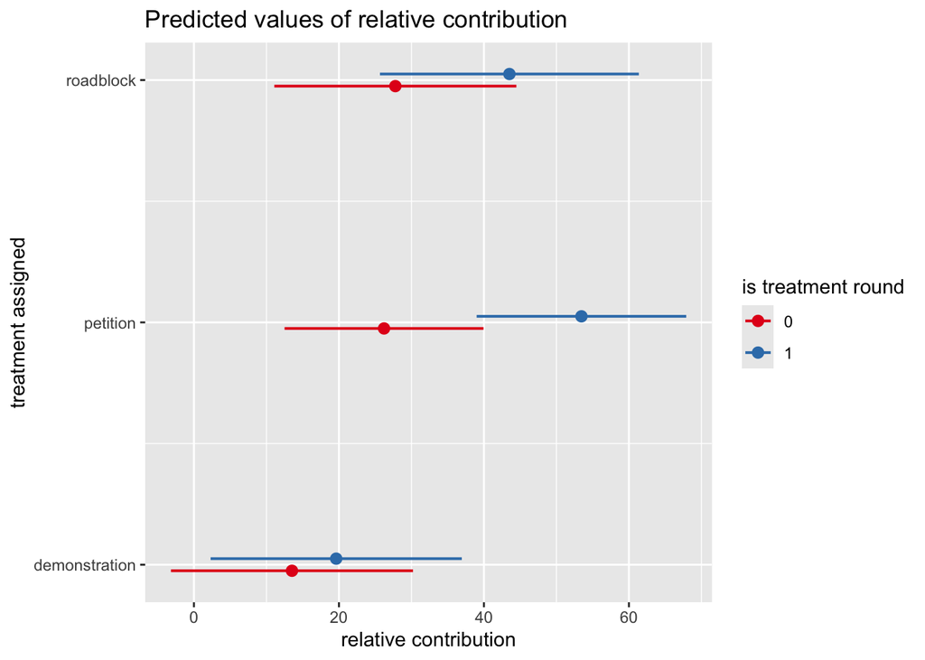

```r
    #alt plots
plot_model(h1.1.lmer,
           type = "int",
           show.values=TRUE,show.p=T,order.terms = T) + coord_flip()
```

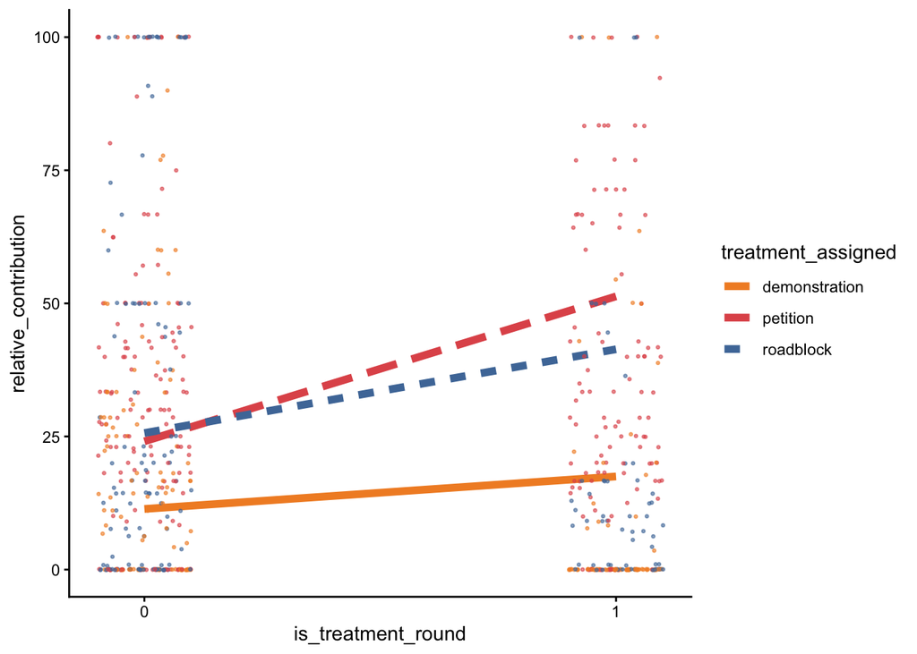

```r
interact_plot(h1.1.lmer,modx = treatment_assigned, pred = is_treatment_round,
              plot.points = T,
              #rug = T,
              jitter = .1,
              point.size = .5,
              #interval = T,
              robust = T,line.thickness = 2,int.type = "confidence",
              colors = treatment_colors) +
  theme_classic()
```

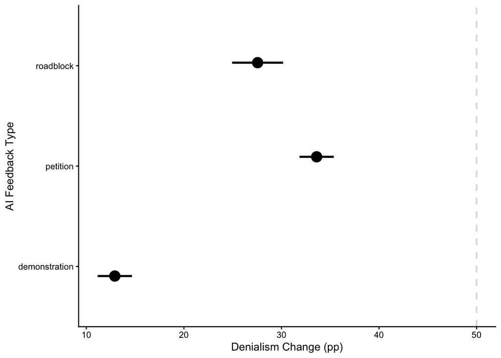

```r
ggerrorplot(df_long,
            x = "treatment_assigned", y = "relative_contribution",
            #color = "is_treatment_round",
            combine = T,
            size = 1,legend = "top",
            position = position_jitter(.2), alpha = .8, orientation =  "horiz", add = "mean_se",
            na.rm = T, sort.val = "asc") +
  geom_hline(yintercept = 50, colour = "darkgray", alpha = .4, size = 0.8, linetype = "dashed") +
  labs(x = "AI Feedback Type", y = "Denialism Change (pp)"#, title = "Conversation effects by condition",
       #color = "is_treatment_round", fill = "is_treatment_round"
       ) +  # Custom legend title
  theme_classic()  +
  theme(legend.title = element_text(size = 10, face = "bold"))
```

```r
#2. ACTIVISM TURNOUT
h2.1.lmer <- lmer(player.chose_activism ~ treatment_assigned + others_contribution_lag + NegDev_lag + PosDev_lag + period +
                    (1 | group_id) + (1 | participant.code),
           data = df_long) #is_treatment_round = 1 only
summary(h2.1.lmer)
```

```
## Linear mixed model fit by REML. t-tests use Satterthwaite's method [
## lmerModLmerTest]
## Formula:
## player.chose_activism ~ treatment_assigned + others_contribution_lag +
##     NegDev_lag + PosDev_lag + period + (1 | group_id) + (1 |
##     participant.code)
##    Data: df_long
##
## REML criterion at convergence: 219.5
##
## Scaled residuals:
##     Min      1Q  Median      3Q     Max
## -2.8824 -0.3415  0.0131  0.3803  3.0874
##
## Random effects:
##  Groups           Name        Variance Std.Dev.
##  participant.code (Intercept) 0.05051  0.2247
##  group_id         (Intercept) 0.00074  0.0272
##  Residual                     0.09426  0.3070
## Number of obs: 252, groups:  participant.code, 36; group_id, 9
##
## Fixed effects:
##                              Estimate Std. Error        df t value Pr(>|t|)
## (Intercept)                   0.42252    0.13966  58.65022    3.03  0.00368 **
## treatment_assignedpetition    0.64648    0.10472   6.89073    6.17  0.00049 ***
## treatment_assignedroadblock   0.38218    0.11828   5.86565    3.23  0.01846 *
## others_contribution_lag       0.00279    0.00133  68.90579    2.10  0.03946 *
## NegDev_lag                   -0.00324    0.00273 226.97635   -1.19  0.23584
## PosDev_lag                    0.00264    0.00182 231.71104    1.45  0.14896
## period                       -0.02776    0.01020 215.57105   -2.72  0.00702 **
## ---
## Signif. codes:  0 '***' 0.001 '**' 0.01 '*' 0.05 '.' 0.1 ' ' 1
##
## Correlation of Fixed Effects:
##               (Intr) trtmnt_ssgndp trtmnt_ssgndr othr__ NgDv_l PsDv_l
## trtmnt_ssgndp -0.350
## trtmnt_ssgndr -0.318  0.461
## othrs_cntr_   -0.026 -0.326        -0.024
## NegDev_lag    -0.259  0.119        -0.026        -0.505
## PosDev_lag    -0.272 -0.013        -0.036        -0.103  0.328
## period        -0.837 -0.011        -0.016        -0.026  0.249  0.241
```

```r
nice_table(pairs(emmeans(h2.1.lmer, pairwise ~ treatment_assigned, adjust = "holm")$contrasts))
```

| contrast | estimate | SE | df | t | p |
| --- | --- | --- | --- | --- | --- |
| (demonstration - petition) - (demonstration - roadblock) | -0.26 | 0.12 | 6.10 | -2.26 | .137 |
| (demonstration - petition) - (petition - roadblock) | -0.91 | 0.19 | 6.60 | -4.82 | .005** |
| (demonstration - roadblock) - (petition - roadblock) | -0.65 | 0.11 | 6.46 | -6.12 | .002** |

```r
# Main-table version: treatment_assigned + period only, no lagged controls -- matches
# the period-only H2 specification used in mainreg.tex; feeds the "Activism Turnout"
# column of tables/results/lmer-interaction.tex
h2.1_main.lmer <- lmer(player.chose_activism ~ treatment_assigned + period +
                    (1 | group_id) + (1 | participant.code),
           data = df_long)
summary(h2.1_main.lmer)
```

```
## Linear mixed model fit by REML. t-tests use Satterthwaite's method [
## lmerModLmerTest]
## Formula:
## player.chose_activism ~ treatment_assigned + period + (1 | group_id) +
##     (1 | participant.code)
##    Data: df_long
##
## REML criterion at convergence: 194.4
##
## Scaled residuals:
##     Min      1Q  Median      3Q     Max
## -3.0471 -0.3479  0.0174  0.3697  3.0820
##
## Random effects:
##  Groups           Name        Variance Std.Dev.
##  participant.code (Intercept) 0.05041  0.2245
##  group_id         (Intercept) 0.00583  0.0763
##  Residual                     0.09551  0.3091
## Number of obs: 252, groups:  participant.code, 36; group_id, 9
##
## Fixed effects:
##                              Estimate Std. Error        df t value Pr(>|t|)
## (Intercept)                   0.47024    0.13692  37.20054    3.43  0.00147 **
## treatment_assignedpetition    0.72321    0.11288   6.00000    6.41  0.00068 ***
## treatment_assignedroadblock   0.39286    0.13492   6.00000    2.91  0.02692 *
## period                       -0.02976    0.00973 215.00005   -3.06  0.00252 **
## ---
## Signif. codes:  0 '***' 0.001 '**' 0.01 '*' 0.05 '.' 0.1 ' ' 1
##
## Correlation of Fixed Effects:
##               (Intr) trtmnt_ssgndp trtmnt_ssgndr
## trtmnt_ssgndp -0.471
## trtmnt_ssgndr -0.394  0.478
## period        -0.782  0.000         0.000
```

```r
#3. WELFARE & EFFICIENCY
h3.1.lmer <- lmer(welfare ~ treatment_assigned * is_treatment_round + period + (1 | group_id) + (1 | participant.code),
           data = df_long)
summary(h3.1.lmer)
```

```
## Linear mixed model fit by REML. t-tests use Satterthwaite's method [
## lmerModLmerTest]
## Formula: welfare ~ treatment_assigned * is_treatment_round + period +
##     (1 | group_id) + (1 | participant.code)
##    Data: df_long
##
## REML criterion at convergence: 6567
##
## Scaled residuals:
##    Min     1Q Median     3Q    Max
## -3.645 -0.553 -0.016  0.639  3.046
##
## Random effects:
##  Groups           Name        Variance Std.Dev.
##  participant.code (Intercept)    0      0.0
##  group_id         (Intercept) 3765     61.4
##  Residual                     2759     52.5
## Number of obs: 610, groups:  participant.code, 56; group_id, 14
##
## Fixed effects:
##                                                Estimate Std. Error      df
## (Intercept)                                     441.107     31.390  11.622
## treatment_assignedpetition                       18.239     40.212  11.265
## treatment_assignedroadblock                      21.926     44.015  11.232
## is_treatment_round                               -0.619     11.122 593.760
## period                                            1.872      1.089 593.855
## treatment_assignedpetition:is_treatment_round    60.076     10.702 595.911
## treatment_assignedroadblock:is_treatment_round  -46.348     12.782 597.275
##                                                t value    Pr(>|t|)
## (Intercept)                                      14.05 0.000000012 ***
## treatment_assignedpetition                        0.45     0.65876
## treatment_assignedroadblock                       0.50     0.62799
## is_treatment_round                               -0.06     0.95566
## period                                            1.72     0.08617 .
## treatment_assignedpetition:is_treatment_round     5.61 0.000000030 ***
## treatment_assignedroadblock:is_treatment_round   -3.63     0.00031 ***
## ---
## Signif. codes:  0 '***' 0.001 '**' 0.01 '*' 0.05 '.' 0.1 ' ' 1
##
## Correlation of Fixed Effects:
##                  (Intr) trtmnt_ssgndp trtmnt_ssgndr is_tr_ period
## trtmnt_ssgndp    -0.768
## trtmnt_ssgndr    -0.701  0.547
## is_trtmnt_r       0.018  0.054         0.051
## period           -0.129  0.002        -0.001        -0.686
## trtmnt_ssgndp:__  0.074 -0.096        -0.052        -0.550  0.000
## trtmnt_ssgndr:__  0.062 -0.048        -0.088        -0.461  0.000
##                  trtmnt_ssgndp:__
## trtmnt_ssgndp
## trtmnt_ssgndr
## is_trtmnt_r
## period
## trtmnt_ssgndp:__
## trtmnt_ssgndr:__  0.479
## optimizer (nloptwrap) convergence code: 0 (OK)
## boundary (singular) fit: see help('isSingular')
```

```r
nice_table(pairs(emmeans(h3.1.lmer, pairwise ~ is_treatment_round:treatment_assigned, adjust = "holm")$contrasts))
```

| contrast | estimate | SE | df | t | p |
| --- | --- | --- | --- | --- | --- |
| (is_treatment_round0 demonstration - is_treatment_round1 demonstration) - (is_treatment_round0 demonstration - is_treatment_round0 petition) | 18.86 | 41.14 | 12.21 | 0.46 | 1.00 |
| (is_treatment_round0 demonstration - is_treatment_round1 demonstration) - (is_treatment_round0 demonstration - is_treatment_round1 petition) | 78.31 | 40.61 | 11.59 | 1.93 | .803 |
| (is_treatment_round0 demonstration - is_treatment_round1 demonstration) - (is_treatment_round0 demonstration - is_treatment_round0 roadblock) | 22.54 | 44.85 | 11.98 | 0.50 | 1.00 |
| (is_treatment_round0 demonstration - is_treatment_round1 demonstration) - (is_treatment_round0 demonstration - is_treatment_round1 roadblock) | -24.42 | 44.75 | 11.86 | -0.55 | 1.00 |
| (is_treatment_round0 demonstration - is_treatment_round1 demonstration) - (is_treatment_round1 demonstration - is_treatment_round0 petition) | 19.48 | 44.90 | 17.27 | 0.43 | 1.00 |
| (is_treatment_round0 demonstration - is_treatment_round1 demonstration) - (is_treatment_round1 demonstration - is_treatment_round1 petition) | 78.93 | 43.08 | 14.64 | 1.83 | .852 |
| (is_treatment_round0 demonstration - is_treatment_round1 demonstration) - (is_treatment_round1 demonstration - is_treatment_round0 roadblock) | 23.16 | 48.30 | 16.08 | 0.48 | 1.00 |
| (is_treatment_round0 demonstration - is_treatment_round1 demonstration) - (is_treatment_round1 demonstration - is_treatment_round1 roadblock) | -23.80 | 46.98 | 14.39 | -0.51 | 1.00 |
| (is_treatment_round0 demonstration - is_treatment_round1 demonstration) - (is_treatment_round0 petition - is_treatment_round1 petition) | 60.08 | 10.71 | 559.25 | 5.61 | < .001*** |
| (is_treatment_round0 demonstration - is_treatment_round1 demonstration) - (is_treatment_round0 petition - is_treatment_round0 roadblock) | 4.31 | 41.70 | 12.89 | 0.10 | 1.00 |
| (is_treatment_round0 demonstration - is_treatment_round1 demonstration) - (is_treatment_round0 petition - is_treatment_round1 roadblock) | -42.66 | 41.60 | 12.76 | -1.03 | .998 |
| (is_treatment_round0 demonstration - is_treatment_round1 demonstration) - (is_treatment_round1 petition - is_treatment_round0 roadblock) | -55.15 | 43.91 | 15.84 | -1.26 | .990 |
| (is_treatment_round0 demonstration - is_treatment_round1 demonstration) - (is_treatment_round1 petition - is_treatment_round1 roadblock) | -102.12 | 42.47 | 13.85 | -2.40 | .546 |
| (is_treatment_round0 demonstration - is_treatment_round1 demonstration) - (is_treatment_round0 roadblock - is_treatment_round1 roadblock) | -46.35 | 12.79 | 560.57 | -3.62 | .025* |
| (is_treatment_round0 demonstration - is_treatment_round0 petition) - (is_treatment_round0 demonstration - is_treatment_round1 petition) | 59.46 | 10.36 | 557.27 | 5.74 | < .001*** |
| (is_treatment_round0 demonstration - is_treatment_round0 petition) - (is_treatment_round0 demonstration - is_treatment_round0 roadblock) | 3.69 | 40.21 | 11.15 | 0.09 | 1.00 |
| (is_treatment_round0 demonstration - is_treatment_round0 petition) - (is_treatment_round0 demonstration - is_treatment_round1 roadblock) | -43.28 | 41.53 | 12.67 | -1.04 | .998 |
| (is_treatment_round0 demonstration - is_treatment_round0 petition) - (is_treatment_round1 demonstration - is_treatment_round0 petition) | 0.62 | 11.12 | 557.27 | 0.06 | 1.00 |
| (is_treatment_round0 demonstration - is_treatment_round0 petition) - (is_treatment_round1 demonstration - is_treatment_round1 petition) | 60.08 | 10.71 | 559.25 | 5.61 | < .001*** |
| (is_treatment_round0 demonstration - is_treatment_round0 petition) - (is_treatment_round1 demonstration - is_treatment_round0 roadblock) | 4.31 | 41.70 | 12.89 | 0.10 | 1.00 |
| (is_treatment_round0 demonstration - is_treatment_round0 petition) - (is_treatment_round1 demonstration - is_treatment_round1 roadblock) | -42.66 | 41.60 | 12.76 | -1.03 | .998 |
| (is_treatment_round0 demonstration - is_treatment_round0 petition) - (is_treatment_round0 petition - is_treatment_round1 petition) | 41.22 | 41.93 | 13.18 | 0.98 | .999 |
| (is_treatment_round0 demonstration - is_treatment_round0 petition) - (is_treatment_round0 petition - is_treatment_round0 roadblock) | -14.55 | 67.30 | 11.16 | -0.22 | 1.00 |
| (is_treatment_round0 demonstration - is_treatment_round0 petition) - (is_treatment_round0 petition - is_treatment_round1 roadblock) | -61.52 | 68.11 | 11.70 | -0.90 | .999 |
| (is_treatment_round0 demonstration - is_treatment_round0 petition) - (is_treatment_round1 petition - is_treatment_round0 roadblock) | -74.01 | 67.59 | 11.35 | -1.09 | .996 |
| (is_treatment_round0 demonstration - is_treatment_round0 petition) - (is_treatment_round1 petition - is_treatment_round1 roadblock) | -120.98 | 67.54 | 11.31 | -1.79 | .862 |
| (is_treatment_round0 demonstration - is_treatment_round0 petition) - (is_treatment_round0 roadblock - is_treatment_round1 roadblock) | -65.21 | 42.12 | 13.41 | -1.55 | .945 |
| (is_treatment_round0 demonstration - is_treatment_round1 petition) - (is_treatment_round0 demonstration - is_treatment_round0 roadblock) | -55.77 | 41.10 | 12.17 | -1.36 | .978 |
| (is_treatment_round0 demonstration - is_treatment_round1 petition) - (is_treatment_round0 demonstration - is_treatment_round1 roadblock) | -102.74 | 41.01 | 12.04 | -2.51 | .495 |
| (is_treatment_round0 demonstration - is_treatment_round1 petition) - (is_treatment_round1 demonstration - is_treatment_round0 petition) | -58.84 | 18.64 | 556.56 | -3.16 | .104 |

[output cut: 75 more lines]

```r
h3.1b.lmer <- lmer(norm_welfare ~ treatment_assigned * is_treatment_round + period + (1 | group_id) + (1 | participant.code),
           data = df_long)
summary(h3.1b.lmer)
```

```
## Linear mixed model fit by REML. t-tests use Satterthwaite's method [
## lmerModLmerTest]
## Formula: norm_welfare ~ treatment_assigned * is_treatment_round + period +
##     (1 | group_id) + (1 | participant.code)
##    Data: df_long
##
## REML criterion at convergence: 2058
##
## Scaled residuals:
##    Min     1Q Median     3Q    Max
## -3.391 -0.655 -0.077  0.644  2.962
##
## Random effects:
##  Groups           Name        Variance Std.Dev.
##  participant.code (Intercept) 0.00     0.00
##  group_id         (Intercept) 1.86     1.36
##  Residual                     1.57     1.25
## Number of obs: 610, groups:  participant.code, 56; group_id, 14
##
## Fixed effects:
##                                                Estimate Std. Error       df
## (Intercept)                                      9.9054     0.6999  11.7080
## treatment_assignedpetition                       0.4045     0.8956  11.2984
## treatment_assignedroadblock                      0.4878     0.9802  11.2602
## is_treatment_round                               0.5863     0.2649 593.9870
## period                                           0.0140     0.0259 594.0893
## treatment_assignedpetition:is_treatment_round    0.9287     0.2549 596.3910
## treatment_assignedroadblock:is_treatment_round   0.4668     0.3044 597.8908
##                                                t value   Pr(>|t|)
## (Intercept)                                      14.15 0.00000001 ***
## treatment_assignedpetition                        0.45    0.66005
## treatment_assignedroadblock                       0.50    0.62829
## is_treatment_round                                2.21    0.02726 *
## period                                            0.54    0.59083
## treatment_assignedpetition:is_treatment_round     3.64    0.00029 ***
## treatment_assignedroadblock:is_treatment_round    1.53    0.12564
## ---
## Signif. codes:  0 '***' 0.001 '**' 0.01 '*' 0.05 '.' 0.1 ' ' 1
##
## Correlation of Fixed Effects:
##                  (Intr) trtmnt_ssgndp trtmnt_ssgndr is_tr_ period
## trtmnt_ssgndp    -0.767
## trtmnt_ssgndr    -0.700  0.547
## is_trtmnt_r       0.019  0.058         0.054
## period           -0.138  0.002        -0.001        -0.686
## trtmnt_ssgndp:__  0.079 -0.103        -0.056        -0.550  0.000
## trtmnt_ssgndr:__  0.066 -0.051        -0.094        -0.461  0.000
##                  trtmnt_ssgndp:__
## trtmnt_ssgndp
## trtmnt_ssgndr
## is_trtmnt_r
## period
## trtmnt_ssgndp:__
## trtmnt_ssgndr:__  0.479
## optimizer (nloptwrap) convergence code: 0 (OK)
## boundary (singular) fit: see help('isSingular')
```

```r
nice_table(pairs(emmeans(h3.1b.lmer, pairwise ~ is_treatment_round:treatment_assigned, adjust = "holm")$contrasts))
```

| contrast | estimate | SE | df | t | p |
| --- | --- | --- | --- | --- | --- |
| (is_treatment_round0 demonstration - is_treatment_round1 demonstration) - (is_treatment_round0 demonstration - is_treatment_round0 petition) | -0.18 | 0.92 | 12.39 | -0.20 | 1.00 |
| (is_treatment_round0 demonstration - is_treatment_round1 demonstration) - (is_treatment_round0 demonstration - is_treatment_round1 petition) | 1.33 | 0.91 | 11.67 | 1.47 | .959 |
| (is_treatment_round0 demonstration - is_treatment_round1 demonstration) - (is_treatment_round0 demonstration - is_treatment_round0 roadblock) | -0.10 | 1.00 | 12.12 | -0.10 | 1.00 |
| (is_treatment_round0 demonstration - is_treatment_round1 demonstration) - (is_treatment_round0 demonstration - is_treatment_round1 roadblock) | 0.95 | 1.00 | 11.98 | 0.96 | .999 |
| (is_treatment_round0 demonstration - is_treatment_round1 demonstration) - (is_treatment_round1 demonstration - is_treatment_round0 petition) | -0.77 | 1.01 | 18.28 | -0.76 | 1.00 |
| (is_treatment_round0 demonstration - is_treatment_round1 demonstration) - (is_treatment_round1 demonstration - is_treatment_round1 petition) | 0.75 | 0.97 | 15.21 | 0.77 | 1.00 |
| (is_treatment_round0 demonstration - is_treatment_round1 demonstration) - (is_treatment_round1 demonstration - is_treatment_round0 roadblock) | -0.68 | 1.09 | 16.90 | -0.63 | 1.00 |
| (is_treatment_round0 demonstration - is_treatment_round1 demonstration) - (is_treatment_round1 demonstration - is_treatment_round1 roadblock) | 0.37 | 1.06 | 14.91 | 0.35 | 1.00 |
| (is_treatment_round0 demonstration - is_treatment_round1 demonstration) - (is_treatment_round0 petition - is_treatment_round1 petition) | 0.93 | 0.26 | 559.71 | 3.64 | .023* |
| (is_treatment_round0 demonstration - is_treatment_round1 demonstration) - (is_treatment_round0 petition - is_treatment_round0 roadblock) | -0.50 | 0.93 | 13.18 | -0.54 | 1.00 |
| (is_treatment_round0 demonstration - is_treatment_round1 demonstration) - (is_treatment_round0 petition - is_treatment_round1 roadblock) | 0.55 | 0.93 | 13.02 | 0.59 | 1.00 |
| (is_treatment_round0 demonstration - is_treatment_round1 demonstration) - (is_treatment_round1 petition - is_treatment_round0 roadblock) | -2.02 | 0.99 | 16.61 | -2.04 | .753 |
| (is_treatment_round0 demonstration - is_treatment_round1 demonstration) - (is_treatment_round1 petition - is_treatment_round1 roadblock) | -0.96 | 0.95 | 14.28 | -1.01 | .998 |
| (is_treatment_round0 demonstration - is_treatment_round1 demonstration) - (is_treatment_round0 roadblock - is_treatment_round1 roadblock) | 0.47 | 0.30 | 561.16 | 1.53 | .971 |
| (is_treatment_round0 demonstration - is_treatment_round0 petition) - (is_treatment_round0 demonstration - is_treatment_round1 petition) | 1.51 | 0.25 | 557.48 | 6.14 | < .001*** |
| (is_treatment_round0 demonstration - is_treatment_round0 petition) - (is_treatment_round0 demonstration - is_treatment_round0 roadblock) | 0.08 | 0.90 | 11.17 | 0.09 | 1.00 |
| (is_treatment_round0 demonstration - is_treatment_round0 petition) - (is_treatment_round0 demonstration - is_treatment_round1 roadblock) | 1.14 | 0.93 | 12.92 | 1.22 | .991 |
| (is_treatment_round0 demonstration - is_treatment_round0 petition) - (is_treatment_round1 demonstration - is_treatment_round0 petition) | -0.59 | 0.26 | 557.48 | -2.21 | .656 |
| (is_treatment_round0 demonstration - is_treatment_round0 petition) - (is_treatment_round1 demonstration - is_treatment_round1 petition) | 0.93 | 0.26 | 559.71 | 3.64 | .023* |
| (is_treatment_round0 demonstration - is_treatment_round0 petition) - (is_treatment_round1 demonstration - is_treatment_round0 roadblock) | -0.50 | 0.93 | 13.18 | -0.54 | 1.00 |
| (is_treatment_round0 demonstration - is_treatment_round0 petition) - (is_treatment_round1 demonstration - is_treatment_round1 roadblock) | 0.55 | 0.93 | 13.02 | 0.59 | 1.00 |
| (is_treatment_round0 demonstration - is_treatment_round0 petition) - (is_treatment_round0 petition - is_treatment_round1 petition) | 1.11 | 0.94 | 13.52 | 1.18 | .993 |
| (is_treatment_round0 demonstration - is_treatment_round0 petition) - (is_treatment_round0 petition - is_treatment_round0 roadblock) | -0.32 | 1.50 | 11.19 | -0.21 | 1.00 |
| (is_treatment_round0 demonstration - is_treatment_round0 petition) - (is_treatment_round0 petition - is_treatment_round1 roadblock) | 0.73 | 1.52 | 11.80 | 0.48 | 1.00 |
| (is_treatment_round0 demonstration - is_treatment_round0 petition) - (is_treatment_round1 petition - is_treatment_round0 roadblock) | -1.84 | 1.51 | 11.40 | -1.22 | .990 |
| (is_treatment_round0 demonstration - is_treatment_round0 petition) - (is_treatment_round1 petition - is_treatment_round1 roadblock) | -0.78 | 1.51 | 11.35 | -0.52 | 1.00 |
| (is_treatment_round0 demonstration - is_treatment_round0 petition) - (is_treatment_round0 roadblock - is_treatment_round1 roadblock) | 0.65 | 0.94 | 13.77 | 0.69 | 1.00 |
| (is_treatment_round0 demonstration - is_treatment_round1 petition) - (is_treatment_round0 demonstration - is_treatment_round0 roadblock) | -1.43 | 0.92 | 12.34 | -1.56 | .940 |
| (is_treatment_round0 demonstration - is_treatment_round1 petition) - (is_treatment_round0 demonstration - is_treatment_round1 roadblock) | -0.38 | 0.92 | 12.18 | -0.41 | 1.00 |
| (is_treatment_round0 demonstration - is_treatment_round1 petition) - (is_treatment_round1 demonstration - is_treatment_round0 petition) | -2.10 | 0.44 | 556.68 | -4.73 | < .001*** |

[output cut: 75 more lines]

```r
heff.lmer <- lmer(efficiency ~ treatment_assigned * is_treatment_round + period + (1 | group_id) + (1 | participant.code),
           data = df_long)
summary(heff.lmer)
```

```
## Linear mixed model fit by REML. t-tests use Satterthwaite's method [
## lmerModLmerTest]
## Formula: efficiency ~ treatment_assigned * is_treatment_round + period +
##     (1 | group_id) + (1 | participant.code)
##    Data: df_long
##
## REML criterion at convergence: 3619
##
## Scaled residuals:
##     Min      1Q  Median      3Q     Max
## -2.8755 -0.5917 -0.0412  0.6079  2.9030
##
## Random effects:
##  Groups           Name        Variance Std.Dev.
##  participant.code (Intercept)  0.0     0.00
##  group_id         (Intercept) 44.5     6.67
##  Residual                     20.6     4.54
## Number of obs: 610, groups:  participant.code, 56; group_id, 14
##
## Fixed effects:
##                                                Estimate Std. Error       df
## (Intercept)                                     73.0014     3.3837  11.2707
## treatment_assignedpetition                       4.9407     4.3467  11.0485
## treatment_assignedroadblock                      6.8726     4.7591  11.0265
## is_treatment_round                               3.6513     0.9617 593.0483
## period                                          -1.1590     0.0942 593.1202
## treatment_assignedpetition:is_treatment_round    7.6514     0.9258 594.5224
## treatment_assignedroadblock:is_treatment_round   3.6649     1.1060 595.4895
##                                                t value             Pr(>|t|)
## (Intercept)                                      21.57  0.00000000016064123 ***
## treatment_assignedpetition                        1.14              0.27973
## treatment_assignedroadblock                       1.44              0.17652
## is_treatment_round                                3.80              0.00016 ***
## period                                          -12.31 < 0.0000000000000002 ***
## treatment_assignedpetition:is_treatment_round     8.26  0.00000000000000091 ***
## treatment_assignedroadblock:is_treatment_round    3.31              0.00098 ***
## ---
## Signif. codes:  0 '***' 0.001 '**' 0.01 '*' 0.05 '.' 0.1 ' ' 1
##
## Correlation of Fixed Effects:
##                  (Intr) trtmnt_ssgndp trtmnt_ssgndr is_tr_ period
## trtmnt_ssgndp    -0.770
## trtmnt_ssgndr    -0.703  0.548
## is_trtmnt_r       0.014  0.043         0.041
## period           -0.104  0.001        -0.001        -0.686
## trtmnt_ssgndp:__  0.059 -0.076        -0.042        -0.550  0.000
## trtmnt_ssgndr:__  0.049 -0.038        -0.070        -0.461  0.000
##                  trtmnt_ssgndp:__
## trtmnt_ssgndp
## trtmnt_ssgndr
## is_trtmnt_r
## period
## trtmnt_ssgndp:__
## trtmnt_ssgndr:__  0.478
## optimizer (nloptwrap) convergence code: 0 (OK)
## boundary (singular) fit: see help('isSingular')
```

```r
#nice_table(pairs(emmeans(heff.lmer, pairwise ~ is_treatment_round:treatment_assigned, adjust = "holm")$emmeans))
```

```r
h1.1clean.lmer <- lmer(relative_contribution ~ treatment_assigned * is_treatment_round + period +
                    (1 | group_id) + (1 | participant.code),
           data = df_long_clean)

h2.1clean.lmer <- lmer(player.chose_activism ~ treatment_assigned + others_contribution_lag + NegDev_lag + PosDev_lag + period +
                    (1 | group_id) + (1 | participant.code),
           data = df_long_clean) #is_treatment_round = 1 only

# Main-table version: treatment_assigned + period only, no lagged controls -- matches
# h2.1_main.lmer; feeds the "Activism Turnout" column of tables/results/lmer-interaction-comp.tex
h2.1clean_main.lmer <- lmer(player.chose_activism ~ treatment_assigned + period +
                    (1 | group_id) + (1 | participant.code),
           data = df_long_clean)

h3.1clean.lmer <- lmer(welfare ~ treatment_assigned * is_treatment_round + period + (1 | group_id) + (1 | participant.code),
           data = df_long_clean)

h3.1bclean.lmer <- lmer(norm_welfare ~ treatment_assigned * is_treatment_round + period + (1 | group_id) + (1 | participant.code),
           data = df_long_clean)

heffclean.lmer <- lmer(efficiency ~ treatment_assigned * is_treatment_round + period + (1 | group_id) + (1 | participant.code),
           data = df_long_clean)
```

### 5.3.3 Tables: All Models

#### 5.3.3.1 Main Preregistered Models (OLS)

```r
#main preregisted effects, compared to control period
#H2 (Activism Turnout) uses model_h2_main_rob: condition + period only, matching
#the period-only specification of the other three outcomes
tab_model(model_h1_ols_rob,model_h2_main_rob,model_h3_ols_rob,model_h3norm_ols_rob,
          show.se = T, #auto.label = T,
          collapse.se=T,
  col.order = c("est","se","p"),
  dv.labels = c("(1) Contribution Rate","(2) Activism Turnout", "(3.1) Welfare", "(3.2) Welfare/sec"),
  p.style = "numeric",digits = 2,
  p.adjust = "holm")
```

1. Contribution Rate
2. Activism Turnout

(3.1) Welfare

(3.2) Welfare/sec

Predictors

Estimates

p

Estimates

p

Estimates

p

Estimates

p

(Intercept)

39.52  
(5.19)

**<0.001**

0.47  
(0.25)

0.115

455.45  
(15.05)

**<0.001**

10.22  
(0.34)

**<0.001**

condition [petition]

25.65  
(10.66)

**0.049**

0.72  
(0.11)

**<0.001**

57.52  
(64.01)

1.000

1.47  
(1.43)

1.000

condition [demonstration]

-0.53  
(8.12)

1.000

-18.61  
(25.32)

1.000

0.19  
(0.70)

1.000

condition [roadblock]

5.64  
(13.19)

1.000

0.39  
(0.17)

0.062

-74.54  
(31.44)

0.072

0.44  
(0.67)

1.000

period

-2.73  
(0.69)

**<0.001**

-0.03  
(0.02)

0.115

2.36  
(3.11)

1.000

0.03  
(0.07)

1.000

Observations

612

252

610

610

R<sup>2</sup> / R<sup>2</sup> adjusted

0.115 / 0.109

0.417 / 0.410

0.174 / 0.169

0.109 / 0.103

```r
library(modelsummary)

# Save clean regression table for the paper (Table \ref{tab:mainreg})
save_reg_table(list("(1) Contribution Rate" = model_h1_ols_rob,
                     "(2) Activism Turnout"  = model_h2_main_rob,
                     "(3.1) Welfare"         = model_h3_ols_rob,
                     "(3.2) Welfare/sec"     = model_h3norm_ols_rob,
                     "Efficiency"            = model_efficiency_rob),
               path = paper_path("tables", "results", "mainreg.tex"))
```

#### 5.3.3.2 Mixed Effects Models

```r
#main effects - OLS
tab_model(h1.lmer,h2.lmer,h3.lmer,h3b.lmer,
          show.se = T, #auto.label = T,
          collapse.se=T,
  col.order = c("est","se","p"),
  dv.labels = c("(1) Contribution Rate","(2) Activism Turnout", "(3.1) Welfare", "(3.2) Welfare/sec"),
  p.style = "numeric",digits = 2,
  p.adjust = "holm")
```

1. Contribution Rate
2. Activism Turnout

(3.1) Welfare

(3.2) Welfare/sec

Predictors

Estimates

p

Estimates

p

Estimates

p

Estimates

p

(Intercept)

39.48  
(4.75)

**<0.001**

106.90  
(14.22)

**<0.001**

455.19  
(16.06)

**<0.001**

10.22  
(0.36)

**<0.001**

condition [petition]

27.40  
(4.02)

**<0.001**

59.55  
(10.34)

**<0.001**

1.52  
(0.25)

**<0.001**

condition [demonstration]

5.60  
(4.31)

0.194

-64.65  
(10.47)

**<0.001**

-1.05  
(11.10)

0.925

0.58  
(0.26)

0.060

condition [roadblock]

15.98  
(4.84)

**0.002**

-26.43  
(11.63)

0.096

-46.88  
(12.47)

**0.001**

1.06  
(0.30)

**0.001**

period

-2.74  
(0.42)

**<0.001**

-2.78  
(1.02)

**0.035**

1.88  
(1.09)

0.171

0.01  
(0.03)

0.588

others contribution lag

0.28  
(0.13)

0.110

NegDev lag

-0.32  
(0.27)

0.298

PosDev lag

0.26  
(0.18)

0.298

Random Effects

σ<sup>2</sup>

418.02

942.62

2758.53

1.57

τ<sub>00</sub>

286.07 <sub>participant.code</sub>

505.05 <sub>participant.code</sub>

0.00 <sub>participant.code</sub>

0.00 <sub>participant.code</sub>

192.84 <sub>group_id</sub>

7.40 <sub>group_id</sub>

3269.19 <sub>group_id</sub>

1.61 <sub>group_id</sub>

ICC

0.53

0.35

N

14 <sub>group_id</sub>

9 <sub>group_id</sub>

14 <sub>group_id</sub>

14 <sub>group_id</sub>

56 <sub>participant.code</sub>

36 <sub>participant.code</sub>

56 <sub>participant.code</sub>

56 <sub>participant.code</sub>

Observations

612

252

610

610

Marginal R<sup>2</sup> / Conditional R<sup>2</sup>

0.071 / 0.567

0.428 / 0.629

0.261 / NA

0.212 / NA

```r
#main effects - mixed effects models
tab_model(h1.lmer,h2.lmer,h3.lmer,h3b.lmer,
          show.se = T, #auto.label = T,
          collapse.se=T,
  col.order = c("est","se","p"),
  dv.labels = c("(1) Contribution Rate","(2) Activism Turnout", "(3.1) Welfare", "(3.2) Welfare/sec"),
  p.style = "numeric",digits = 2,
  p.adjust = "holm")
```

1. Contribution Rate
2. Activism Turnout

(3.1) Welfare

(3.2) Welfare/sec

Predictors

Estimates

p

Estimates

p

Estimates

p

Estimates

p

(Intercept)

39.48  
(4.75)

**<0.001**

106.90  
(14.22)

**<0.001**

455.19  
(16.06)

**<0.001**

10.22  
(0.36)

**<0.001**

condition [petition]

27.40  
(4.02)

**<0.001**

59.55  
(10.34)

**<0.001**

1.52  
(0.25)

**<0.001**

condition [demonstration]

5.60  
(4.31)

0.194

-64.65  
(10.47)

**<0.001**

-1.05  
(11.10)

0.925

0.58  
(0.26)

0.060

condition [roadblock]

15.98  
(4.84)

**0.002**

-26.43  
(11.63)

0.096

-46.88  
(12.47)

**0.001**

1.06  
(0.30)

**0.001**

period

-2.74  
(0.42)

**<0.001**

-2.78  
(1.02)

**0.035**

1.88  
(1.09)

0.171

0.01  
(0.03)

0.588

others contribution lag

0.28  
(0.13)

0.110

NegDev lag

-0.32  
(0.27)

0.298

PosDev lag

0.26  
(0.18)

0.298

Random Effects

σ<sup>2</sup>

418.02

942.62

2758.53

1.57

τ<sub>00</sub>

286.07 <sub>participant.code</sub>

505.05 <sub>participant.code</sub>

0.00 <sub>participant.code</sub>

0.00 <sub>participant.code</sub>

192.84 <sub>group_id</sub>

7.40 <sub>group_id</sub>

3269.19 <sub>group_id</sub>

1.61 <sub>group_id</sub>

ICC

0.53

0.35

N

14 <sub>group_id</sub>

9 <sub>group_id</sub>

14 <sub>group_id</sub>

14 <sub>group_id</sub>

56 <sub>participant.code</sub>

36 <sub>participant.code</sub>

56 <sub>participant.code</sub>

56 <sub>participant.code</sub>

Observations

612

252

610

610

Marginal R<sup>2</sup> / Conditional R<sup>2</sup>

0.071 / 0.567

0.428 / 0.629

0.261 / NA

0.212 / NA

```r
#MAIN - interaction - mixed effects models - full sample
#H2 (Activism Turnout) uses h2.1_main.lmer: treatment_assigned + period only, matching
#the period-only specification used in mainreg.tex (lags tested separately in model_lag.tex)
tab_model(h1.1.lmer, h2.1_main.lmer,h3.1.lmer,h3.1b.lmer,
          show.se = T, #auto.label = T,
          collapse.se=T,
  col.order = c("est","se","p"),
  dv.labels = c("(1) Contribution Rate","(2) Activism Turnout", "(3.1) Welfare", "(3.2) Welfare/sec"),
  p.style = "numeric",digits = 3,
  p.adjust = "holm")
```

1. Contribution Rate
2. Activism Turnout

(3.1) Welfare

(3.2) Welfare/sec

Predictors

Estimates

p

Estimates

p

Estimates

p

Estimates

p

(Intercept)

29.971  
(8.596)

**0.003**

0.470  
(0.137)

**0.002**

441.107  
(31.390)

**<0.001**

9.905  
(0.700)

**<0.001**

treatment assigned  
[petition]

12.700  
(10.919)

0.476

0.723  
(0.113)

**<0.001**

18.239  
(40.212)

1.000

0.405  
(0.896)

1.000

treatment assigned  
[roadblock]

14.258  
(11.947)

0.476

0.393  
(0.135)

**0.005**

21.926  
(44.015)

1.000

0.488  
(0.980)

1.000

is treatment round

6.100  
(4.324)

0.476

-0.619  
(11.122)

1.000

0.586  
(0.265)

0.136

period

-2.742  
(0.423)

**<0.001**

-0.030  
(0.010)

**0.005**

1.872  
(1.089)

0.345

0.014  
(0.026)

1.000

treatment assigned  
[petition] × is treatment  
round

21.130  
(4.158)

**<0.001**

60.076  
(10.702)

**<0.001**

0.929  
(0.255)

**0.002**

treatment assigned  
[roadblock] × is  
treatment round

9.635  
(4.962)

0.211

-46.348  
(12.782)

**0.002**

0.467  
(0.304)

0.503

Random Effects

σ<sup>2</sup>

418.01

0.10

2758.69

1.57

τ<sub>00</sub>

286.08 <sub>participant.code</sub>

0.05 <sub>participant.code</sub>

0.00 <sub>participant.code</sub>

0.00 <sub>participant.code</sub>

197.54 <sub>group_id</sub>

0.01 <sub>group_id</sub>

3765.48 <sub>group_id</sub>

1.86 <sub>group_id</sub>

ICC

0.54

0.37

N

14 <sub>group_id</sub>

9 <sub>group_id</sub>

14 <sub>group_id</sub>

14 <sub>group_id</sub>

56 <sub>participant.code</sub>

36 <sub>participant.code</sub>

56 <sub>participant.code</sub>

56 <sub>participant.code</sub>

Observations

612

252

610

610

Marginal R<sup>2</sup> / Conditional R<sup>2</sup>

0.138 / 0.600

0.406 / 0.626

0.281 / NA

0.244 / NA

```r
# Save clean regression table for the paper (Table A2, \ref{tab:lmer-interaction})
save_reg_table(list("(1) Contribution Rate" = h1.1.lmer,
                     "(2) Activism Turnout"  = h2.1_main.lmer,
                     "(3.1) Welfare"         = h3.1.lmer,
                     "(3.2) Welfare/sec"     = h3.1b.lmer,
                     "Efficiency"            = heff.lmer),
               path = paper_path("tables", "results", "lmer-interaction.tex"))


#interaction - mixed effects models - complete responses only
#H2 (Activism Turnout) uses h2.1clean_main.lmer: treatment_assigned + period only,
#matching the period-only specification used in the full-sample table
tab_model(h1.1clean.lmer, h2.1clean_main.lmer,h3.1clean.lmer,h3.1bclean.lmer,
          show.se = T, #auto.label = T,
          collapse.se=T,
  col.order = c("est","se","p"),
  dv.labels = c("(1) Contribution Rate","(2) Activism Turnout", "(3.1) Welfare", "(3.2) Welfare/sec"),
  p.style = "numeric",digits = 3,
  p.adjust = "holm")
```

1. Contribution Rate
2. Activism Turnout

(3.1) Welfare

(3.2) Welfare/sec

Predictors

Estimates

p

Estimates

p

Estimates

p

Estimates

p

(Intercept)

34.055  
(8.376)

**<0.001**

0.470  
(0.137)

**0.002**

448.073  
(42.754)

**<0.001**

10.085  
(0.950)

**<0.001**

treatment assigned  
[petition]

4.624  
(10.820)

1.000

0.723  
(0.113)

**<0.001**

15.995  
(56.254)

1.000

0.355  
(1.248)

1.000

treatment assigned  
[roadblock]

-4.454  
(12.933)

1.000

0.393  
(0.135)

**0.005**

-10.405  
(67.236)

1.000

-0.231  
(1.492)

1.000

is treatment round

7.358  
(4.437)

0.294

8.433  
(10.901)

1.000

0.818  
(0.265)

**0.011**

period

-2.946  
(0.450)

**<0.001**

-0.030  
(0.010)

**0.005**

0.572  
(1.107)

1.000

-0.019  
(0.027)

1.000

treatment assigned  
[petition] × is treatment  
round

21.554  
(4.129)

**<0.001**

60.133  
(10.144)

**<0.001**

0.930  
(0.246)

**0.001**

treatment assigned  
[roadblock] × is  
treatment round

10.618  
(4.935)

0.128

-45.524  
(12.125)

**0.001**

0.488  
(0.294)

0.393

Random Effects

σ<sup>2</sup>

409.15

0.10

2469.68

1.46

τ<sub>00</sub>

68.97 <sub>participant.code</sub>

0.05 <sub>participant.code</sub>

0.00 <sub>participant.code</sub>

0.00 <sub>participant.code</sub>

168.86 <sub>group_id</sub>

0.01 <sub>group_id</sub>

5336.65 <sub>group_id</sub>

2.62 <sub>group_id</sub>

ICC

0.37

0.37

N

9 <sub>group_id</sub>

9 <sub>group_id</sub>

9 <sub>group_id</sub>

9 <sub>group_id</sub>

36 <sub>participant.code</sub>

36 <sub>participant.code</sub>

36 <sub>participant.code</sub>

36 <sub>participant.code</sub>

Observations

504

252

504

504

Marginal R<sup>2</sup> / Conditional R<sup>2</sup>

0.149 / 0.462

0.406 / 0.626

0.405 / NA

0.282 / NA

```r
# Save clean regression table for the paper (Table A5, \ref{tab:mainreg_controls})
save_reg_table(list("(1) Contribution Rate" = h1.1clean.lmer,
                     "(2) Activism Turnout"  = h2.1clean_main.lmer,
                     "(3.1) Welfare"         = h3.1clean.lmer,
                     "(3.2) Welfare/sec"     = h3.1bclean.lmer,
                     "Efficiency"            = heffclean.lmer),
               path = paper_path("tables", "results", "lmer-interaction-comp.tex"))
```

# 6 Exploratory Analyses

## 6.1 Robustness: Controls (Age, Gender, Education, etc.)

Moved to its own script, `03_robustness_controls.Rmd` – builds Tables A3 (`tables/results/mainreg_controls2.tex`) and A4 (`tables/results/mainreg_more_controls2.tex`) from `df_long`’s own questionnaire columns.

## 6.2 Temporal Dynamics: Contribution Trends

```r
#contribution rate over time - interaction terms not sig (no sig differences in contribution rates over time across conditions (but general decline over time (ME)))
model_trend <- lm(relative_contribution ~ condition * period,
                  data = df_long)
vcov_trend <- vcovCL(model_trend, cluster = ~ group_id)
coeftest(model_trend, vcov = vcov_trend)
```

```
##
## t test of coefficients:
##
##                               Estimate Std. Error t value        Pr(>|t|)
## (Intercept)                      36.48       5.03    7.26 0.0000000000012 ***
## conditionpetition                34.98      16.95    2.06           0.039 *
## conditiondemonstration           15.81      25.73    0.61           0.539
## conditionroadblock               30.85      36.03    0.86           0.392
## period                           -1.93       0.83   -2.32           0.020 *
## conditionpetition:period         -1.37       1.39   -0.99           0.324
## conditiondemonstration:period    -2.01       2.32   -0.86           0.388
## conditionroadblock:period        -2.81       2.67   -1.05           0.292
## ---
## Signif. codes:  0 '***' 0.001 '**' 0.01 '*' 0.05 '.' 0.1 ' ' 1
```

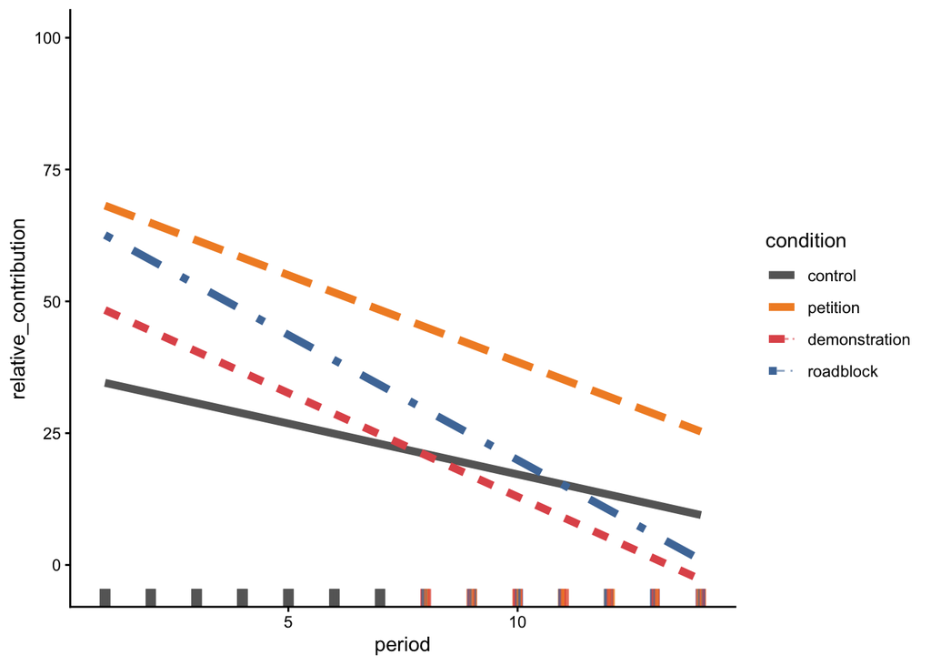

```r
interact_plot(model_trend,modx = condition, pred = period,
              #plot.points = T,
              rug = T,jitter = .1,
              #interval = T,
              robust = T,line.thickness = 2,int.type = "confidence",
              colors = condition_colors) +
  theme_classic()
```

```r
# Activism turnout over time (treatment rounds only) - no sig difference over time
model_trend_activism <- lm(
  activism_rate ~ condition * period,
  data = df_long %>% filter(is_treatment_round == 1, !is.na(chose_activism)))
vcov_trend_activism <- vcovCL(model_trend_activism, cluster = ~ group_id)
coeftest(model_trend_activism, vcov = vcov_trend_activism)
```

```
##
## t test of coefficients:
##
##                               Estimate Std. Error t value            Pr(>|t|)
## (Intercept)                    101.339      9.990   10.14 <0.0000000000000002
## conditiondemonstration         -34.673     50.584   -0.69                0.49
## conditionroadblock              -8.482     41.796   -0.20                0.84
## period                          -1.339      0.986   -1.36                0.18
## conditiondemonstration:period   -3.423      3.960   -0.86                0.39
## conditionroadblock:period       -2.232      2.880   -0.78                0.44
##
## (Intercept)                   ***
## conditiondemonstration
## conditionroadblock
## period
## conditiondemonstration:period
## conditionroadblock:period
## ---
## Signif. codes:  0 '***' 0.001 '**' 0.01 '*' 0.05 '.' 0.1 ' ' 1
```